# Package TateyamaVegetation Documentation

## 1 `APG`

**Documentation:**

```
data/APG　植物目録 米倉浩司・梶田忠 (2007-)
植物和名ー学名インデックスYList を利用させていただきました。

Description:

     data/APG　植物目録 米倉浩司・梶田忠 (2007-)
     植物和名ー学名インデックスYList を利用させていただきました。

Usage:

     data(APG)

Format:

     An object of class `data.frame`.

Examples:

     APG
```

**Examples (from .Rd):**

```r
### Name: APG
### Title: data/APG　植物目録 米倉浩司・梶田忠 (2007-)
###   植物和名ー学名インデックスYList を利用させていただきました。
### Aliases: APG
### Keywords: datasets

### ** Examples

APG
```

**Executed Example:**

```r
try(example('APG', package = 'TateyamaVegetation', echo=TRUE, ask=FALSE), silent = TRUE)
```

```
##
## APG> APG
##          ID0 ID                        種名                                                                                               学名             科名         科名.和.
## 1   24001010  1                  クロマゴケ                                                     Andreaeobryum macrosporum Steere et B.M.Murray ANDREAEOBRYACEAE     クロマゴケ科
## 2   32101010  2              ミドリツノゴケ                                                        Folioceros appendiculatus (Steph.) J.Haseg.  ANTHOCEROTACEAE       ツノゴケ科
## 3   32101010  3              ミドリツノゴケ                                           Folioceros glandulosus (Lehm. et Lindenb.) D.C.Bharadwaj  ANTHOCEROTACEAE       ツノゴケ科
## 4  111101010  4                マンネンスギ                                                     Dendrolycopodium dendroideum (Michx.) A.Haines    LYCOPODIACEAE ヒカゲノカズラ科
## 5  111101010  5        ミヤマヒカゲノカズラ                                                                   Diphasiastrum alpinum (L.) Holub    LYCOPODIACEAE ヒカゲノカズラ科
## 6  111101010  6        ミヤマヒカゲノカズラ                  Diphasiastrum alpinum (L.) Holub  var. planiramulosum (Takeda) P.C.Li et J.Z.Wang    LYCOPODIACEAE ヒカゲノカズラ科
## 7  111101010  7                アスヒカズラ                                                               Diphasiastrum complanatum (L.) Holub    LYCOPODIACEAE ヒカゲノカズラ科
## 8  111101010  8 ナンゴクアスヒカズラ(temp.)                                           Diphasiastrum complanatum (L.) Holub  var. glaucum Ching    LYCOPODIACEAE ヒカゲノカズラ科
## 9  111101010  9 ナンゴクアスヒカズラ(temp.)                                                      Diphasiastrum multispicatum (J.H.Wilce) Holub    LYCOPODIACEAE ヒカゲノカズラ科
## 10 111101010 10        タカネヒカゲノカズラ                                                     Diphasiastrum nikoense (Franch. et Sav.) Holub    LYCOPODIACEAE ヒカゲノカズラ科
## 11 111101010 11      ニイタカヒカゲノカズラ                                                              Diphasiastrum veitchii (Christ) Holub    LYCOPODIACEAE ヒカゲノカズラ科
## 12 111101010 12              オオスギカズラ                                                                 Hupersia taiwanensis (Ching) Holub    LYCOPODIACEAE ヒカゲノカズラ科
```

[output cut: 100 more lines]

## 2 `DT_VCrepo`

**Documentation:**

```
報告書用植生調査集計表　Data Table of Vegetation Chronosequence

Description:

     報告書用植生調査集計表　Data Table of Vegetation Chronosequence

Usage:

     DT_VCrepo(plot_name = "Mimatsu")

Arguments:

plot_name:

Examples:

     DT_VCrepo("Mimatsu")
     DT_VCrepo("Arimine")

     # for (i in plt$plot_name) {DT_VCrepo(i)}
```

**Examples (from .Rd):**

```r
### Name: DT_VCrepo
### Title: 報告書用植生調査集計表　Data Table of Vegetation Chronosequence
### Aliases: DT_VCrepo

### ** Examples


DT_VCrepo("Mimatsu")
DT_VCrepo("Arimine")

# for (i in plt$plot_name) {DT_VCrepo(i)}
```

**Executed Example:**

```r
try(example('DT_VCrepo', package = 'TateyamaVegetation', echo=TRUE, ask=FALSE), silent = TRUE)
```

```
##
## DT_VCr> DT_VCrepo("Mimatsu")
##
## DT_VCr> DT_VCrepo("Arimine")
##
## DT_VCr> # for (i in plt$plot_name) {DT_VCrepo(i)}
## DT_VCr>
## DT_VCr>
## DT_VCr>
## DT_VCr>
```

## 3 `Domin_Krajina`

**Documentation:**

```
クロステーブル作成用　被度→被度階級(Domin_Krajina)

Description:

     クロステーブル作成用　被度→被度階級(Domin_Krajina)

Usage:

     Domin_Krajina(cv)

Arguments:

      cv:

Examples:

     Domin_Krajina(26.5)

     cover<-seq(0,100,1)
     plot(cover, Domin_Krajina(cover),type="l")
```

**Examples (from .Rd):**

```r
### Name: Domin_Krajina
### Title: クロステーブル作成用　被度→被度階級(Domin_Krajina)
### Aliases: Domin_Krajina

### ** Examples


Domin_Krajina(26.5)

cover<-seq(0,100,1)
plot(cover, Domin_Krajina(cover),type="l")
```

**Executed Example:**

```r
try(example('Domin_Krajina', package = 'TateyamaVegetation', echo=TRUE, ask=FALSE), silent = TRUE)
```

```
##
## Dmn_Kr> Domin_Krajina(26.5)
## [1] 6
##
## Dmn_Kr> cover<-seq(0,100,1)
##
## Dmn_Kr> plot(cover, Domin_Krajina(cover),type="l")
```

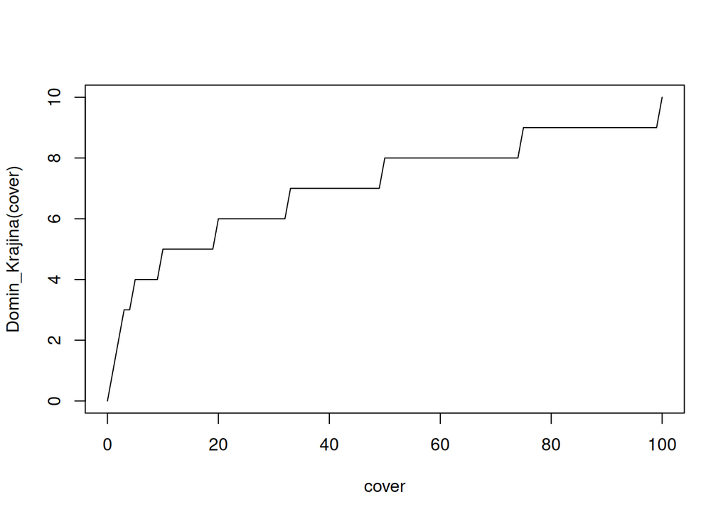

## 4 `EncodingExchange`

**Documentation:**

```
csvファイルのエンコーディング変換

Description:

     上書きします。必要に応じて事前にバックアップしておいてください。

Usage:

     EncodingExchange(filename = "test.csv", en_old = "cp932", en_new = "utf-8")

Arguments:

  en_old: original fileEncoding　defaulut　"cp932"

  en_new: new fileEncoding defaulut　"utf-8"

Examples:

     #EncodingExchange(filename="H30植生調査野帳_美松.csv",en_old="cp932",en_new="utf-8")

     　#EncodingExchange(filename="H31植生調査野帳_有峰.csv",en_old="cp932",en_new="utf-8")
```

**Examples (from .Rd):**

```r
### Name: EncodingExchange
### Title: csvファイルのエンコーディング変換
### Aliases: EncodingExchange

### ** Examples


#EncodingExchange(filename="H30植生調査野帳_美松.csv",en_old="cp932",en_new="utf-8")

　#EncodingExchange(filename="H31植生調査野帳_有峰.csv",en_old="cp932",en_new="utf-8")
```

**Executed Example:**

```r
try(example('EncodingExchange', package = 'TateyamaVegetation', echo=TRUE, ask=FALSE), silent = TRUE)
```

```
##
## EncdnE> #EncodingExchange(filename="H30植生調査野帳_美松.csv",en_old="cp932",en_new="utf-8")
## EncdnE>
## EncdnE> 　#EncodingExchange(filename="H31植生調査野帳_有峰.csv",en_old="cp932",en_new="utf-8")
## EncdnE>
## EncdnE>
## EncdnE>
## EncdnE>
## EncdnE>
## EncdnE>
```

## 5 `FieldNote_Arimine2019_raw`

**Documentation:**

```
data/整理前の野帳生データ(サンプル)　FieldNote_Arimine2019_raw

Description:

     data/整理前の野帳生データ(サンプル)　FieldNote_Arimine2019_raw

Usage:

     data(FieldNote_Arimine2019_raw)

Format:

     An object of class `tbl_df`.

Examples:

     FieldNote_Arimine2019_raw
```

**Examples (from .Rd):**

```r
### Name: FieldNote_Arimine2019_raw
### Title: data/整理前の野帳生データ(サンプル)　FieldNote_Arimine2019_raw
### Aliases: FieldNote_Arimine2019_raw
### Keywords: datasets

### ** Examples

FieldNote_Arimine2019_raw
```

**Executed Example:**

```r
try(example('FieldNote_Arimine2019_raw', package = 'TateyamaVegetation', echo=TRUE, ask=FALSE), silent = TRUE)
```

```
##
## FN_A20> FieldNote_Arimine2019_raw
## # A tibble: 897 × 10
##    サブプロット 階層  種名           DK2000 被度2007 被度2013 被度2019 X        no   II_
##           <dbl> <chr> <chr>           <dbl>    <dbl>    <dbl>    <dbl> <lgl> <dbl> <dbl>
##  1            1 B2    アオダモ          0        1          1      1   NA        1   1
##  2            1 B2    イタヤカエデ      0.5      0.5        1      0.3 NA        6   0.5
##  3            1 B2    ウリハダカエデ    0       12          3      0.5 NA        7   5
##  4            1 B2    ウワミズザクラ    4        5          5      0.8 NA        8   4
##  5            1 B2    オオカメノキ      5       10          5     14   NA        9   5
##  6            1 B2    オオバクロモジ    5       18         15     10   NA       10   6
##  7            1 B2    コシアブラ        0        1          1      4   NA       11   1
##  8            1 B2    コマユミ          2        0          0      0.1 NA       12   0
##  9            1 B2    サワフタギ        2        4          3      2   NA       13   2
## 10            1 B2    タムシバ         NA       NA          2      3   NA       25  NA
## # ℹ 887 more rows
```

## 6 `FieldNote_CheckCorrect`

**Documentation:**

```
野帳の整理をします。
生野帳データの階層クラスの確認、修正、未入力データの補完をします
　サブプロット、階層、種名の順でソートします。
　サブプロットに同一種が複数ある場合は被度を合算し統一します

Description:

     野帳の整理をします。
     生野帳データの階層クラスの確認、修正、未入力データの補完をします
     　サブプロット、階層、種名の順でソートします。
     　サブプロットに同一種が複数ある場合は被度を合算し統一します

Usage:

     FieldNote_CheckCorrect(d = FieldNote)

Arguments:

KAISO_colnm:

Examples:

     d<-FieldNote_Arimine2019_raw
     FieldNote_CheckCorrect(d)
```

**Examples (from .Rd):**

```r
### Name: FieldNote_CheckCorrect
### Title: 野帳の整理をします。
###   生野帳データの階層クラスの確認、修正、未入力データの補完をします
###   　サブプロット、階層、種名の順でソートします。
###   　サブプロットに同一種が複数ある場合は被度を合算し統一します
### Aliases: FieldNote_CheckCorrect

### ** Examples

d<-FieldNote_Arimine2019_raw
FieldNote_CheckCorrect(d)
```

**Executed Example:**

```r
try(example('FieldNote_CheckCorrect', package = 'TateyamaVegetation', echo=TRUE, ask=FALSE), silent = TRUE)
```

```
##
## FlN_CC> d<-FieldNote_Arimine2019_raw
##
## FlN_CC> FieldNote_CheckCorrect(d)
## # A tibble: 873 × 7
##    サブプロット 階層  種名           DK2000 被度2007 被度2013 被度2019
##           <dbl> <chr> <chr>           <dbl>    <dbl>    <dbl>    <dbl>
##  1            1 B2    アオダモ          0        1          1      1
##  2            1 B2    イタヤカエデ      0.5      0.5        1      0.3
##  3            1 B2    ウリハダカエデ    0       12          3      0.5
##  4            1 B2    ウワミズザクラ    4        5          5      0.8
##  5            1 B2    オオカメノキ      5       10          5     14
##  6            1 B2    オオバクロモジ    5       18         15     10
##  7            1 B2    コシアブラ        0        1          1      4
##  8            1 B2    コマユミ          2        0          0      0.1
##  9            1 B2    サワフタギ        2        4          3      2
## 10            1 B2    タムシバ          0        0          2      3
## # ℹ 863 more rows
```

## 7 `Fig_DominanceValue`

**Documentation:**

```
報告書用作図　総合優占度経年変化 Figure of chronosequence for dominant
variance

Description:

     報告書用作図　総合優占度経年変化 Figure of chronosequence for
     dominant variance

Usage:

     Fig_DominanceValue(plot_name = "Joudosan")

Arguments:

plot_name:

Examples:

     library(dplyr)
     library(ggrepel)

     Fig_DominanceValue("Kaminokodaira")
     Fig_DominanceValue("Arimine")
     Fig_DominanceValue("Matsuotoge")

     Fig_DominanceValue(plt$plot_name[9])

     par(mfrow=c(3,4))
     for(i in plt$plot_name)Fig_DominanceValue(i)

     par(mfrow=c(1,1))
```

**Examples (from .Rd):**

```r
### Name: Fig_DominanceValue
### Title: 報告書用作図　総合優占度経年変化 Figure of chronosequence for
###   dominant variance
### Aliases: Fig_DominanceValue

### ** Examples

library(dplyr)
library(ggrepel)

Fig_DominanceValue("Kaminokodaira")
Fig_DominanceValue("Arimine")
Fig_DominanceValue("Matsuotoge")

Fig_DominanceValue(plt$plot_name[9])

par(mfrow=c(3,4))
for(i in plt$plot_name)Fig_DominanceValue(i)

par(mfrow=c(1,1))
```

**Executed Example:**

```
##
## Fg_DmV> library(dplyr)
##
## Fg_DmV> library(ggrepel)
##
## Fg_DmV> Fig_DominanceValue("Kaminokodaira")
```

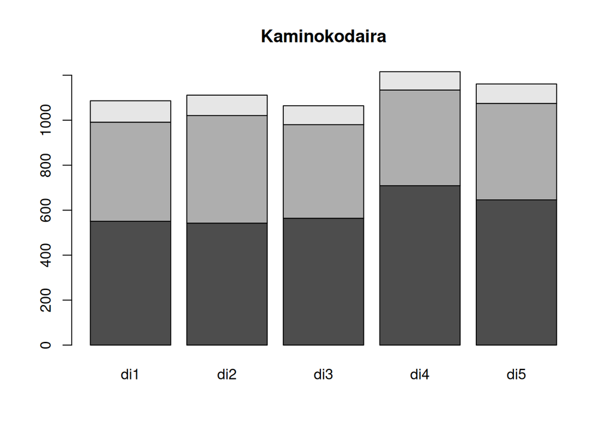

```
##
## Fg_DmV> Fig_DominanceValue("Arimine")
```

```r
try(example('Fig_DominanceValue', package = 'TateyamaVegetation', echo=TRUE, ask=FALSE), silent = TRUE)
```

## 8 `Fig_FrequencyCoverage`

**Documentation:**

```
報告書用作図　出現頻度−平均被度

Description:

     報告書用作図　出現頻度−平均被度

Usage:

     Fig_FrequencyCoverage(
       d = VCrepo,
       plot_name = "Arimine",
       x = "f5",
       y = "c5",
       sp = "sp"
     )

Arguments:

       d: data frame of tibble VCrepo

       x: column name of frequency

       y: column name of coverage

      sp: column name of species

Examples:

     library(ggplot2)
     Fig_FrequencyCoverage(plot_name="Mimatsu")
     Fig_FrequencyCoverage(plot_name="Arimine")
     Fig_FrequencyCoverage(plot_name="Arimine",x="f3",y="c3")
```

**Examples (from .Rd):**

```r
### Name: Fig_FrequencyCoverage
### Title: 報告書用作図　出現頻度−平均被度
### Aliases: Fig_FrequencyCoverage

### ** Examples

library(ggplot2)
Fig_FrequencyCoverage(plot_name="Mimatsu")
Fig_FrequencyCoverage(plot_name="Arimine")
Fig_FrequencyCoverage(plot_name="Arimine",x="f3",y="c3")
```

**Executed Example:**

```
##
## Fg_FrC> library(ggplot2)
##
## Fg_FrC> Fig_FrequencyCoverage(plot_name="Mimatsu")
```

[figure not shown]

```
##
## Fg_FrC> Fig_FrequencyCoverage(plot_name="Arimine")
```

[figure not shown]

```
##
## Fg_FrC> Fig_FrequencyCoverage(plot_name="Arimine",x="f3",y="c3")
```

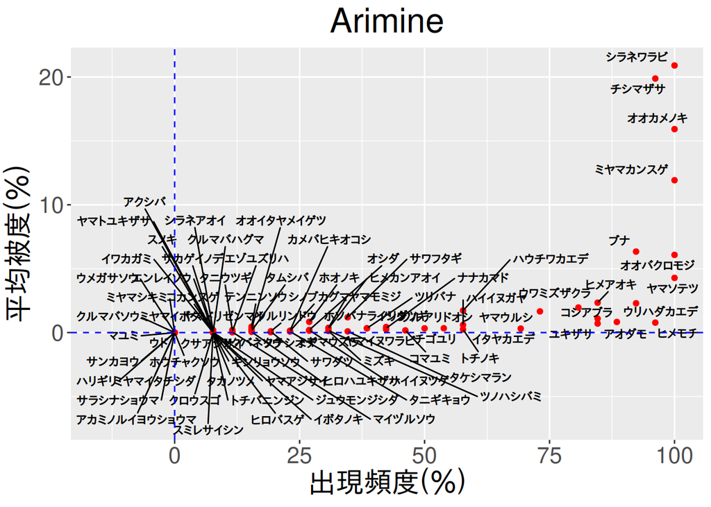

```r
try(example('Fig_FrequencyCoverage', package = 'TateyamaVegetation', echo=TRUE, ask=FALSE), silent = TRUE)
```

## 9 `Fig_FrequencyDominace`

**Documentation:**

```
報告書用作図　出現頻度−総合優占度

Description:

     報告書用作図　出現頻度−総合優占度

Usage:

     Fig_FrequencyDominace(
       d = VCrepo,
       plot_name = "Arimine",
       x = "f5",
       y = "di5",
       sp = "sp"
     )

Arguments:

       d: data frame of tibble VCrepo

       x: column name of frequency

       y: column name of coverage

      sp: column name of species

Examples:

     　library(ggplot2)
     　library(ggrepel)

     Fig_FrequencyDominace(plot_name="Mimatsu")
     Fig_FrequencyDominace(plot_name="Arimine")
     Fig_FrequencyDominace(plot_name="Arimine",x="f3",y="c3")
```

**Examples (from .Rd):**

```r
### Name: Fig_FrequencyDominace
### Title: 報告書用作図　出現頻度−総合優占度
### Aliases: Fig_FrequencyDominace

### ** Examples

　library(ggplot2)
　library(ggrepel)

Fig_FrequencyDominace(plot_name="Mimatsu")
Fig_FrequencyDominace(plot_name="Arimine")
Fig_FrequencyDominace(plot_name="Arimine",x="f3",y="c3")
```

**Executed Example:**

```
##
## Fg_FrD> 　library(ggplot2)
##
## Fg_FrD> 　library(ggrepel)
##
## Fg_FrD> Fig_FrequencyDominace(plot_name="Mimatsu")
```

[figure not shown]

```
##
## Fg_FrD> Fig_FrequencyDominace(plot_name="Arimine")
```

[figure not shown]

```
##
## Fg_FrD> Fig_FrequencyDominace(plot_name="Arimine",x="f3",y="c3")
```

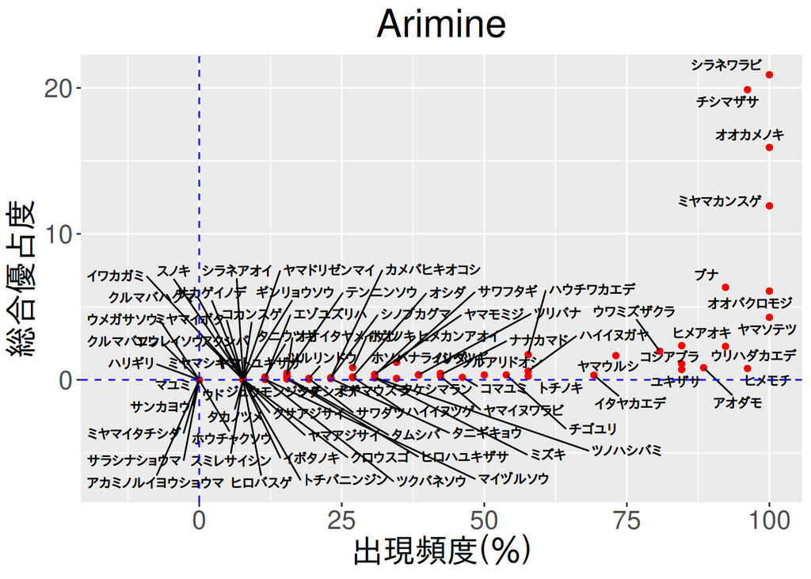

```r
try(example('Fig_FrequencyDominace', package = 'TateyamaVegetation', echo=TRUE, ask=FALSE), silent = TRUE)
```

## 10 `FloraListMaker`

**Documentation:**

```
html植物目録の作成

Description:

     # 米倉浩司・梶田忠 (2003-) 「BG Plants
     和名－学名インデックス」（YList），http://ylist.info」

Usage:

     FloraListMaker(spj = sp0, memo = NA)

Arguments:

     spj: 和名

    memo: メモ

Value:

     htmlリスト

Examples:

     spj <- c("ブナ","コナラ","スギ","アカミノイヌツゲ","イタヤカエデ","アオカラムシ","ミズナラ")
     (fl.<-  FloraListMaker(spj))
     memo.<-c("位山","平井","平井","平井","キャンパス","位山","名古屋","位山")
     (fl.<-  FloraListMaker(spj,memo.))

     # 植生調査植物目録
     sp0<-unique(vv$sp)#'
     (fl. <- FloraListMaker(sp0))

     # cat(fl.,file="data_raw/test_FloraList.html")  # html保存

     # 植生調査植物目録(美松・有峰)
     sp0<-unique(subset(vv,plot=="Mimatsu")$sp)
     # cat(FloraListMaker(sp0),file="data_raw/FloraList_Mimatsu.html")

     sp0<-unique(subset(vv,plot=="Arimine")$sp)
     # cat(FloraListMaker(sp0),file="data_raw/FloraList_Arimine.html")

      #期末植物目録
       d<-flora2
     　memo<-paste("【森】",d$forest_code,"【植】",d$vevetation_code,"【外】",d$NonNative_code)
     　str(memo)
     　#cat(FloraListMaker(flora2$spj,memo=memo),file="FloraList_V.html")
```

**Examples (from .Rd):**

```r
### Name: FloraListMaker
### Title: html植物目録の作成
### Aliases: FloraListMaker

### ** Examples

spj <- c("ブナ","コナラ","スギ","アカミノイヌツゲ","イタヤカエデ","アオカラムシ","ミズナラ")
(fl.<-  FloraListMaker(spj))
memo.<-c("位山","平井","平井","平井","キャンパス","位山","名古屋","位山")
(fl.<-  FloraListMaker(spj,memo.))

# 植生調査植物目録
sp0<-unique(vv$sp)#'
(fl. <- FloraListMaker(sp0))

# cat(fl.,file="data_raw/test_FloraList.html")  # html保存

# 植生調査植物目録(美松・有峰)
sp0<-unique(subset(vv,plot=="Mimatsu")$sp)
# cat(FloraListMaker(sp0),file="data_raw/FloraList_Mimatsu.html")

sp0<-unique(subset(vv,plot=="Arimine")$sp)
# cat(FloraListMaker(sp0),file="data_raw/FloraList_Arimine.html")

 #期末植物目録
  d<-flora2
　memo<-paste("【森】",d$forest_code,"【植】",d$vevetation_code,"【外】",d$NonNative_code)
　str(memo)
　#cat(FloraListMaker(flora2$spj,memo=memo),file="FloraList_V.html")
```

**Executed Example:**

```r
try(example('FloraListMaker', package = 'TateyamaVegetation', echo=TRUE, ask=FALSE), silent = TRUE)
```

```
##
## FlrLsM> spj <- c("ブナ","コナラ","スギ","アカミノイヌツゲ","イタヤカエデ","アオカラムシ","ミズナラ")
##
## FlrLsM> (fl.<-  FloraListMaker(spj))
## [1] "<div style=\"text-align:left; margin-top:20px;\"> <font size=\"+2\" face=\"ＭＳ ゴシック,平成ゴシック\">植物目録</font><br><br> <font size=\"+1\" face=\"ＭＳ ゴシック,平成ゴシック\"> 5科 6属 7種 </font><br><br> </div><pre><table> <tr><td height=30 valign=\"bottom\"><font size=+1; face='Arial'>CUPRESSACEAE&emsp;ヒノキ科</font>…
##
## FlrLsM> memo.<-c("位山","平井","平井","平井","キャンパス","位山","名古屋","位山")
##
## FlrLsM> (fl.<-  FloraListMaker(spj,memo.))
## [1] "<div style=\"text-align:left; margin-top:20px;\"> <font size=\"+2\" face=\"ＭＳ ゴシック,平成ゴシック\">植物目録</font><br><br> <font size=\"+1\" face=\"ＭＳ ゴシック,平成ゴシック\"> 5科 6属 7種 </font><br><br> </div><pre><table> <tr><td height=30 valign=\"bottom\"><font size=+1; face='Arial'>CUPRESSACEAE&emsp;ヒノキ科</font>…
##
## FlrLsM> # 植生調査植物目録
## FlrLsM> sp0<-unique(vv$sp)#'
##
## FlrLsM> (fl. <- FloraListMaker(sp0))
## カヤツリグサ科 水面 はリストにありません[1] "<div style=\"text-align:left; margin-top:20px;\"> <font size=\"+2\" face=\"ＭＳ ゴシック,平成ゴシック\">植物目録</font><br><br> <font size=\"+1\" face=\"ＭＳ ゴシック,平成ゴシック\"> 77科 189属 294種 </font><br><br> </div><pre><table> <tr><td height=30 valign=\"bottom\"><font size=+1; face='Arial'>LYC…
##
## FlrLsM> # cat(fl.,file="data_raw/test_FloraList.html")  # html保存
## FlrLsM>
## FlrLsM> # 植生調査植物目録(美松・有峰)
## FlrLsM> sp0<-unique(subset(vv,plot=="Mimatsu")$sp)
##
## FlrLsM> # cat(FloraListMaker(sp0),file="data_raw/FloraList_Mimatsu.html")
## FlrLsM>
## FlrLsM> sp0<-unique(subset(vv,plot=="Arimine")$sp)
##
## FlrLsM> # cat(FloraListMaker(sp0),file="data_raw/FloraList_Arimine.html")
## FlrLsM>
## FlrLsM>  #期末植物目録
## FlrLsM>   d<-flora2
##
## FlrLsM> 　memo<-paste("【森】",d$forest_code,"【植】",d$vevetation_code,"【外】",d$NonNative_code)
##
## FlrLsM> 　str(memo)
##  chr [1:343] "【森】 NA 【植】 0000-0-1000-0 【外】 弘追01001-弥美1110011001-天大0000010000000-室0010010000000000000-弥00100" "【森】 1001-000-1 【植】 9812-0-0000-8 【外】 NA" ...
##
## FlrLsM> 　#cat(FloraListMaker(flora2$spj,memo=memo),file="FloraList_V.html")
## FlrLsM>
## FlrLsM>
## FlrLsM>
## FlrLsM>
```

## 11 `ForestFloraCode`

**Documentation:**

```
森林調査での植物目録の各調査区における胸高断面積割合コードの作成
9-10はAに変換

Description:

     森林調査での植物目録の各調査区における胸高断面積割合コードの作成
     9-10はAに変換

Usage:

     ForestFloraCode(cod = m[["オオシラビソ"]])

Arguments:

     cod:

Examples:

     ForestFloraCode(1:10)
```

**Examples (from .Rd):**

```r
### Name: ForestFloraCode
### Title: 森林調査での植物目録の各調査区における胸高断面積割合コードの作成
###   9-10はAに変換
### Aliases: ForestFloraCode

### ** Examples


ForestFloraCode(1:10)
```

**Executed Example:**

```r
try(example('ForestFloraCode', package = 'TateyamaVegetation', echo=TRUE, ask=FALSE), silent = TRUE)
```

```
##
## FrstFC> ForestFloraCode(1:10)
## [1] "1234-567-8"
```

## 12 `ForestFloraMatrix`

**Documentation:**

```
森林調査での各調査区-出現全種の行列表

Description:

     森林調査での各調査区-出現全種の行列表

Usage:

     ForestFloraMatrix(d = dd5)

Arguments:

       d:

Examples:

     m<-ForestFloraMatrix(dd5)
     head(m)
     sp<-names(m)[-1]
     df <- data.frame(sp,code_forest=)

     ForestFloraCode(cod=m[[c("オオシラビソ")]])

     fc<-c(); for( i in sp)fc<-c(fc,ForestFloraCode(cod=m[[i]]))
      forest_code<-data.frame(sp,forest_code=fc)
      # usethis::use_data(forest_code)
```

**Examples (from .Rd):**

```r
### Name: ForestFloraMatrix
### Title: 森林調査での各調査区-出現全種の行列表
### Aliases: ForestFloraMatrix

### ** Examples

m<-ForestFloraMatrix(dd5)
head(m)
sp<-names(m)[-1]
df <- data.frame(sp,code_forest=)

ForestFloraCode(cod=m[[c("オオシラビソ")]])

fc<-c(); for( i in sp)fc<-c(fc,ForestFloraCode(cod=m[[i]]))
 forest_code<-data.frame(sp,forest_code=fc)
 # usethis::use_data(forest_code)
```

**Executed Example:**

```r
try(example('ForestFloraMatrix', package = 'TateyamaVegetation', echo=TRUE, ask=FALSE), silent = TRUE)
```

```
##
## FrstFM> m<-ForestFloraMatrix(dd5)
##
## FrstFM> head(m)
## # A tibble: 6 × 37
## # Groups:   plot [6]
##   plot  アオダモ ウリハダカエデ ウワミズザクラ キハダ コシアブラ  スギ トチノキ ハウチワカエデ  ブナ ホオノキ ミズキ ミズナラ ヤマモミジ イタヤカエデ ウダイカンバ シナノキ ナナカマド
##   <fct>    <dbl>          <dbl>          <dbl>  <dbl>      <dbl> <dbl>    <dbl>          <dbl> <dbl>    <dbl>  <dbl>    <dbl>      <dbl>        <dbl>        <dbl>    <dbl>      <dbl>
## 1 Bijo…        1              1              1      1          1    10        1              1     1        1      1        1          1            0            0        0          0
## 2 Buna…        0              1              1      1          1     7        1              1     2        2      1        1          1            1            1        1          1
## 3 Buna…        0              1              1      1          0     5        0              1     5        1      1        0          1            0            1        0          1
## 4 Kami…        1              0              1      0          1     6        0              1     1        0      0        1          0            0            0        1          1
## 5 Mats…        0              0              0      0          0     0        0              0     0        0      0        0          0            0            0        0          1
## 6 Mima…        0              0              0      0          0     0        0              0     0        0      0        0          0            0            0        0          1
## # ℹ 19 more variables: ハリギリ <dbl>, コミネカエデ <dbl>, タムシバ <dbl>, リョウブ <dbl>, オオカメノキ <dbl>, オオシラビソ <dbl>, キタゴヨウ <dbl>, クロベ <dbl>,
## #   ケヤマハンノキ <dbl>, コメツガ <dbl>, ダケカンバ <dbl>, ネコシデ <dbl>, マルバマンサク <dbl>, ミネカエデ <dbl>, オガラバナ <dbl>, オノエヤナギ <dbl>, ミヤマハンノキ <dbl>,
## #   ツリバナ <dbl>, ヤマウルシ <dbl>
##
## FrstFM> sp<-names(m)[-1]
##
## FrstFM> df <- data.frame(sp,code_forest=)
```

## 13 `ForestTrees`

**Documentation:**

```
data/ForestTrees

Description:

     data/ForestTrees

Usage:

     data(ForestTrees)

Format:

     An object of class `data.frame`.

Examples:

     str(ForestTrees)
     head(ForestTrees)
```

**Examples (from .Rd):**

```r
### Name: ForestTrees
### Title: data/ForestTrees
### Aliases: ForestTrees
### Keywords: datasets

### ** Examples

str(ForestTrees)
head(ForestTrees)
```

**Executed Example:**

```r
try(example('ForestTrees', package = 'TateyamaVegetation', echo=TRUE, ask=FALSE), silent = TRUE)
```

```
##
## FrstTr> str(ForestTrees)
## 'data.frame':    3821 obs. of  20 variables:
##  $ pn  : int  1 1 1 1 1 1 1 1 1 1 ...
##  $ plot: chr  "Bijodaira" "Bijodaira" "Bijodaira" "Bijodaira" ...
##  $ lb  : int  1 2 550 551 552 553 554 555 556 3 ...
##  $ sp  : chr  "ミズナラ" "スギ" "スギ" "スギ" ...
##  $ d01 : num  NA NA 53.5 54.2 47.3 23.1 86.5 36.6 75.8 NA ...
##  $ d02 : num  NA 10.4 51.9 56.7 48.4 23.2 86.5 36 76.5 NA ...
##  $ d03 : num  10.3 11 52.1 58 49.1 23 87.3 35.6 77.5 10.9 ...
##  $ d04 : num  11.2 11.5 51.8 59.2 49.6 22.9 87.7 36.2 78.4 11.9 ...
##  $ d05 : num  12.1 12 52.1 60.4 50.5 22.9 89.2 36.5 79.4 12.9 ...
##  $ d06 : num  13.3 12.7 52.2 61.7 51.1 22.7 89.1 36.8 80.6 13.9 ...
##  $ d07 : num  14.2 13.7 52.3 63 52.5 22.8 89.8 37.2 81.6 15.1 ...
##  $ f01 : int  NA NA 3 4 4 2 4 3 5 NA ...
```

[output cut: 17 more lines]

## 14 `LandMarks`

**Documentation:**

```
data/LandMarks　中島さんのデータ

Description:

     data/LandMarks　中島さんのデータ

Usage:

     data(LandMarks)

Format:

     An object of class `data.frame`.

Examples:

     head(LandMarks)
```

**Examples (from .Rd):**

```r
### Name: LandMarks
### Title: data/LandMarks　中島さんのデータ
### Aliases: LandMarks
### Keywords: datasets

### ** Examples

head(LandMarks)
```

**Executed Example:**

```r
try(example('LandMarks', package = 'TateyamaVegetation', echo=TRUE, ask=FALSE), silent = TRUE)
```

```
##
## LndMrk> head(LandMarks)
##        plot      sp    lb     x     y        z memo
## 1 Bijodaira stream1 渓流1 31.31  0.32 1029.983
## 2 Bijodaira stream1 渓流2 30.01  5.20 1030.603
## 3 Bijodaira stream1 渓流3 27.54 10.57 1031.363
## 4 Bijodaira stream1 渓流4 25.00 16.99 1031.563
## 5 Bijodaira stream1 渓流5 24.45 20.55 1031.692
## 6 Bijodaira stream1 渓流6 25.55 25.05 1032.322
```

## 15 `NonNativePlants`

**Documentation:**

```
data/ 立山外来植物調査(大田道人・山下寿之・吉田めぐみ)

Description:

     data/ 立山外来植物調査(大田道人・山下寿之・吉田めぐみ)

Usage:

     data(vv5)

Format:

     An object of class `tbl_df`.

Source:

     "第Ⅳ期外来種調査報告書用全体表.csv", @examples NonNativePlants
     NonNativePlants$sp SpeciesNameCheck(NonNativePlants$sp)
```

**Executed Example:**

```r
try(example('NonNativePlants', package = 'TateyamaVegetation', echo=TRUE, ask=FALSE), silent = TRUE)
```

## 16 `PlotSpecies_1to4`

**Documentation:**

```
各調査区の1〜4期の出現種と各期被度合計 ※　1期については　Domin_Krajina

Description:

     各調査区の1〜4期の出現種と各期被度合計
     ※　1期については　Domin_Krajina

Usage:

     PlotSpecies_1to4(site = "Mimatsu")

Arguments:

    site: ex.　"Arimine"

Value:

     data.frame

Examples:

     ( df <-　PlotSpecies_1to4 ("Mimatsu"))
      #

      ( df2 <-　PlotSpecies_1to4 ("Arimine"))
      # write.csv(df2, "data_raw/PlotSpecies有峰.csv")
```

**Examples (from .Rd):**

```r
### Name: PlotSpecies_1to4
### Title: 各調査区の1〜4期の出現種と各期被度合計
###   ※　1期については　Domin_Krajina
### Aliases: PlotSpecies_1to4

### ** Examples


( df <-　PlotSpecies_1to4 ("Mimatsu"))
 #

 ( df2 <-　PlotSpecies_1to4 ("Arimine"))
 # write.csv(df2, "data_raw/PlotSpecies有峰.csv")
```

**Executed Example:**

```r
try(example('PlotSpecies_1to4', package = 'TateyamaVegetation', echo=TRUE, ask=FALSE), silent = TRUE)
```

```
##
## PlS_14> ( df <-　PlotSpecies_1to4 ("Mimatsu"))
##                          c01    c02     c03     c04
## アイイタドリ             0.0    0.0    0.10    0.10
## アカショウマ             0.0    0.0    6.00    6.00
## アキカラマツ             1.0    6.0    1.00    1.00
## アクシバ                 0.0    0.0    0.00    0.00
## イグサ                   0.0    0.0    0.10    0.10
## イタドリ                12.0    5.0   23.00   23.00
## イヌガンソク             0.0    0.0    0.00    0.00
## イヌワラビ               0.0    5.0    1.60    1.60
## イブキコゴメグサ         0.5    0.0    0.00    0.00
## イワオウギ               8.0    0.0    0.00    0.00
## イワカガミ              10.0   13.0    3.50    3.50
## イワナシ                 5.5    5.0    1.90    1.90
## ウラジロタデ             0.0    0.0    0.00    0.00
## ウラジロナナカマド       0.0    2.0    3.00    3.00
## ウラジロヨウラク         0.0    0.0    0.00    0.00
## エンレイソウ             4.5   10.0    5.48    5.48
## オオイタドリ            20.0   85.0   93.00   93.00
## オオカメノキ            19.5   18.5   11.90   11.90
## オオシラビソ            77.5  126.0   63.40   63.40
## オオバコ                 0.0    0.0    0.00    0.00
## オオバショリマ           0.0   11.0    5.00    5.00
## オオバスノキ            37.5   69.0   46.30   46.30
## オオバタケシマラン       1.5    1.0    1.60    1.60
## オオハナウド             0.0    0.0    1.00    1.00
## オオバノヨツバムグラ     2.5    6.5    0.80    0.80
## オガラバナ              48.0   88.5   25.00   25.00
## オシダ                   0.5    0.0    1.00    1.00
## オニシモツケ             0.0   15.0    6.00    6.00
## オノエヤナギ            21.0   39.5   20.00   20.00
## カニコウモリ             0.5    1.5    0.80    0.80
## キオン                   0.5    0.0    0.00    0.00
## キソチドリ               1.0    0.0    0.00    0.00
## キヌガサソウ             2.5    3.0    1.20    1.20
## クマイチゴ               0.0    1.0    0.50    0.50
## クロウスゴ              19.0   14.5    9.20    9.20
## クロツリバナ            17.0   25.0   16.70   16.70
## クロトウヒレン           0.0    0.0    1.00    1.00
```

[output cut: 152 more lines]

```
## ミヤマシキミ               0.0    5.0   0.00   0.00
## ヤマアジサイ               0.0    0.5   0.20   0.20
## ヤマイヌワラビ             0.0    7.0   6.10   6.10
## ヤマウルシ                 5.5   40.0  43.50  43.50
## ヤマソテツ                69.5   86.5 135.00 135.00
## ヤマトユキザサ             0.0    2.5   0.50   0.50
## ヤマドリゼンマイ           0.5    0.5   2.80   2.80
## ヤマモミジ                 0.0   11.5  10.40  10.40
## ユキザサ                  50.0   58.0  13.70  13.70
##
## PlS_14>  # write.csv(df2, "data_raw/PlotSpecies有峰.csv")
## PlS_14>
## PlS_14>
## PlS_14>
## PlS_14>
```

## 17 `RData_APG`

**Documentation:**

```
APG植物目録() 米倉浩司・梶田忠 (2007-) 植物和名ー学名インデックスYList
を利用させていただきました

Description:

     APG植物目録() 米倉浩司・梶田忠 (2007-)
     植物和名ー学名インデックスYList を利用させていただきました

Usage:

     RData_APG()

Examples:

     head(APG)
     sp.<-c("コイワカガミ","オオバユキザサ","コガネギク","イ","コゴメグサ","タテヤマオウギ")
     sp..<-c("イワカガミ","ヤマトユキザサ","アキノキリンソウ","イグサ","イブキコゴメグサ","イワオウギ")
     cat("以下はAPGリストにありません")
     data.frame(sp=sp.[!is.element(sp.,APG$種名)])
     data.frame(sp=sp..[!is.element(sp.,APG$種名)])
     is.element(c("コイワカガミ","オオバユキザサ","コガネギク","イ","コゴメグサ","タテヤマオウギ"),YList$別名)
     is.element(c("イワカガミ","ヤマトユキザサ","アキノキリンソウ","イグサ","イブキコゴメグサ","イワオウギ"),YList$和名)
```

**Examples (from .Rd):**

```r
### Name: RData_APG
### Title: APG植物目録() 米倉浩司・梶田忠 (2007-)
###   植物和名ー学名インデックスYList を利用させていただきました
### Aliases: RData_APG

### ** Examples

head(APG)
sp.<-c("コイワカガミ","オオバユキザサ","コガネギク","イ","コゴメグサ","タテヤマオウギ")
sp..<-c("イワカガミ","ヤマトユキザサ","アキノキリンソウ","イグサ","イブキコゴメグサ","イワオウギ")
cat("以下はAPGリストにありません")
data.frame(sp=sp.[!is.element(sp.,APG$種名)])
data.frame(sp=sp..[!is.element(sp.,APG$種名)])
is.element(c("コイワカガミ","オオバユキザサ","コガネギク","イ","コゴメグサ","タテヤマオウギ"),YList$別名)
is.element(c("イワカガミ","ヤマトユキザサ","アキノキリンソウ","イグサ","イブキコゴメグサ","イワオウギ"),YList$和名)
```

**Executed Example:**

```r
try(example('RData_APG', package = 'TateyamaVegetation', echo=TRUE, ask=FALSE), silent = TRUE)
```

```
##
## RD_APG> head(APG)
##         ID0 ID                 種名                                                                              学名             科名         科名.和.             属名 フィールド6
## 1  24001010  1           クロマゴケ                                    Andreaeobryum macrosporum Steere et B.M.Murray ANDREAEOBRYACEAE     クロマゴケ科    Andreaeobryum
## 2  32101010  2       ミドリツノゴケ                                       Folioceros appendiculatus (Steph.) J.Haseg.  ANTHOCEROTACEAE       ツノゴケ科       Folioceros
## 3  32101010  3       ミドリツノゴケ                          Folioceros glandulosus (Lehm. et Lindenb.) D.C.Bharadwaj  ANTHOCEROTACEAE       ツノゴケ科       Folioceros
## 4 111101010  4         マンネンスギ                                    Dendrolycopodium dendroideum (Michx.) A.Haines    LYCOPODIACEAE ヒカゲノカズラ科 Dendrolycopodium
## 5 111101010  5 ミヤマヒカゲノカズラ                                                  Diphasiastrum alpinum (L.) Holub    LYCOPODIACEAE ヒカゲノカズラ科    Diphasiastrum
## 6 111101010  6 ミヤマヒカゲノカズラ Diphasiastrum alpinum (L.) Holub  var. planiramulosum (Takeda) P.C.Li et J.Z.Wang    LYCOPODIACEAE ヒカゲノカズラ科    Diphasiastrum
##                                     学名.２  X 英名 X.1      ID.1   Engler.family X.2 X.3 X.4 X.5
## 1                 Andreaeobryum macrosporum NA           24001010    Andreaeaceae  NA  NA  NA  NA
## 2                 Folioceros appendiculatus NA           32101010 Anthocerotaceae  NA  NA  NA  NA
## 3                    Folioceros glandulosus NA           32101010 Anthocerotaceae  NA  NA  NA  NA
## 4              Dendrolycopodium dendroideum NA          111101010   Lycopodiaceae  NA  NA  NA  NA
## 5                     Diphasiastrum alpinum NA          111101010   Lycopodiaceae  NA  NA  NA  NA
## 6 Diphasiastrum alpinum var. planiramulosum NA          111101010   Lycopodiaceae  NA  NA  NA  NA
##
## RD_APG> sp.<-c("コイワカガミ","オオバユキザサ","コガネギク","イ","コゴメグサ","タテヤマオウギ")
##
## RD_APG> sp..<-c("イワカガミ","ヤマトユキザサ","アキノキリンソウ","イグサ","イブキコゴメグサ","イワオウギ")
##
## RD_APG> cat("以下はAPGリストにありません")
## 以下はAPGリストにありません
## RD_APG> data.frame(sp=sp.[!is.element(sp.,APG$種名)])
##               sp
## 1   コイワカガミ
## 2 オオバユキザサ
## 3     コガネギク
## 4             イ
## 5     コゴメグサ
## 6 タテヤマオウギ
##
## RD_APG> data.frame(sp=sp..[!is.element(sp.,APG$種名)])
##                 sp
## 1       イワカガミ
## 2   ヤマトユキザサ
## 3 アキノキリンソウ
## 4           イグサ
## 5 イブキコゴメグサ
## 6       イワオウギ
##
## RD_APG> is.element(c("コイワカガミ","オオバユキザサ","コガネギク","イ","コゴメグサ","タテヤマオウギ"),YList$別名)
```

## 18 `RData_ForestTrees`

**Documentation:**

```
data/RData

Description:

     data/RData

Usage:

     RData_ForestTrees()

Examples:

     str(ForestTrees)
     head(ForestTrees)
```

**Examples (from .Rd):**

```r
### Name: RData_ForestTrees
### Title: data/RData
### Aliases: RData_ForestTrees

### ** Examples

str(ForestTrees)
head(ForestTrees)
```

**Executed Example:**

```r
try(example('RData_ForestTrees', package = 'TateyamaVegetation', echo=TRUE, ask=FALSE), silent = TRUE)
```

```
##
## RDt_FT> str(ForestTrees)
## 'data.frame':    3821 obs. of  20 variables:
##  $ pn  : int  1 1 1 1 1 1 1 1 1 1 ...
##  $ plot: chr  "Bijodaira" "Bijodaira" "Bijodaira" "Bijodaira" ...
##  $ lb  : int  1 2 550 551 552 553 554 555 556 3 ...
##  $ sp  : chr  "ミズナラ" "スギ" "スギ" "スギ" ...
##  $ d01 : num  NA NA 53.5 54.2 47.3 23.1 86.5 36.6 75.8 NA ...
##  $ d02 : num  NA 10.4 51.9 56.7 48.4 23.2 86.5 36 76.5 NA ...
##  $ d03 : num  10.3 11 52.1 58 49.1 23 87.3 35.6 77.5 10.9 ...
##  $ d04 : num  11.2 11.5 51.8 59.2 49.6 22.9 87.7 36.2 78.4 11.9 ...
##  $ d05 : num  12.1 12 52.1 60.4 50.5 22.9 89.2 36.5 79.4 12.9 ...
##  $ d06 : num  13.3 12.7 52.2 61.7 51.1 22.7 89.1 36.8 80.6 13.9 ...
##  $ d07 : num  14.2 13.7 52.3 63 52.5 22.8 89.8 37.2 81.6 15.1 ...
##  $ f01 : int  NA NA 3 4 4 2 4 3 5 NA ...
```

[output cut: 17 more lines]

## 19 `RData_LandMarks`

**Documentation:**

```
data/RData 　中島さんのデータ

Description:

     data/RData 　中島さんのデータ

Usage:

     RData_LandMarks()

Examples:

     head(LandMarks)
```

**Examples (from .Rd):**

```r
### Name: RData_LandMarks
### Title: data/RData 　中島さんのデータ
### Aliases: RData_LandMarks

### ** Examples

head(LandMarks)
```

**Executed Example:**

```r
try(example('RData_LandMarks', package = 'TateyamaVegetation', echo=TRUE, ask=FALSE), silent = TRUE)
```

```
##
## RDt_LM> head(LandMarks)
##        plot      sp    lb     x     y        z memo
## 1 Bijodaira stream1 渓流1 31.31  0.32 1029.983
## 2 Bijodaira stream1 渓流2 30.01  5.20 1030.603
## 3 Bijodaira stream1 渓流3 27.54 10.57 1031.363
## 4 Bijodaira stream1 渓流4 25.00 16.99 1031.563
## 5 Bijodaira stream1 渓流5 24.45 20.55 1031.692
## 6 Bijodaira stream1 渓流6 25.55 25.05 1032.322
```

## 20 `RData_PlotProfile`

**Documentation:**

```
data/RData

Description:

     data/RData

Usage:

     RData_PlotProfile()

Examples:

     head(PlotProfile)
```

**Examples (from .Rd):**

```r
### Name: RData_PlotProfile
### Title: data/RData
### Aliases: RData_PlotProfile

### ** Examples

head(PlotProfile)
```

**Executed Example:**

```r
try(example('RData_PlotProfile', package = 'TateyamaVegetation', echo=TRUE, ask=FALSE), silent = TRUE)
```

```
##
## RDt_PP> head(PlotProfile)
```

## 21 `RData_VegetationSurveyYears`

**Documentation:**

```
data/RData 植生調査実施年

Description:

     data/RData 植生調査実施年

Usage:

     RData_VegetationSurveyYears()

Examples:

     VegetationSurveyYears
```

**Examples (from .Rd):**

```r
### Name: RData_VegetationSurveyYears
### Title: data/RData 植生調査実施年
### Aliases: RData_VegetationSurveyYears

### ** Examples

VegetationSurveyYears
```

**Executed Example:**

```r
try(example('RData_VegetationSurveyYears', package = 'TateyamaVegetation', echo=TRUE, ask=FALSE), silent = TRUE)
```

```
##
## RD_VSY> VegetationSurveyYears
## # A tibble: 10 × 6
##    plot_name     Vegetation001 Vegetation002 Vegetation003 Vegetation004 Vegetation005
##    <chr>         <chr>         <chr>         <chr>         <chr>         <chr>
##  1 Bijodaira     DK1998        被度2002      被度2008      被度2014      被度2021
##  2 Bunazaka      DK1998        被度2002      被度2008      被度2014      被度2020
##  3 Bunadaira     DK1999        被度2005      被度2011      被度2018      被度2023
##  4 Kaminokodaira DK2000        被度2003      被度2009      被度2015      被度2023
##  5 Midagahara    DK1999        被度2005      被度2010      被度2017      被度2021
##  6 Mimatsu       DK1999        被度2006      被度2012      被度2018      被度2025
##  7 Matsuotoge    DK1998        被度2004      被度2010      被度2016      被度2022
##  8 Kagamiishi    DK1999        被度2004      被度2010      被度2016      被度2022
##  9 Joudosan      DK2000        被度2006      被度2012      被度2018      被度2023
## 10 Arimine       DK2000        被度2007      被度2013      被度2019      被度2025
```

## 22 `RData_flora`

**Documentation:**

```
立山植生モニタリング調査の植物目録

Description:

     立山植生モニタリング調査の植物目録

     立山植生モニタリング調査の植物目録

Usage:

     RData_flora()

     RData_flora()

Examples:

     head(flora)
     flora[flora$美松!="",c("spj","sp")]
     sp.<-c("ブナ","ハイマツ","リュウキュウマツ","イソマツ")
     cat("以下はfloraリストにありません")
     data.frame(sp=sp.[!is.element(sp.,flora$spj)])


     head(flora)
     flora[flora$美松!="",c("spj","sp")]
     sp.<-c("ブナ","ハイマツ","リュウキュウマツ","イソマツ")
     cat("以下はfloraリストにありません")
     data.frame(sp=sp.[!is.element(sp.,flora$spj)])
```

**Examples (from .Rd):**

```r
### Name: RData_flora
### Title: 立山植生モニタリング調査の植物目録
### Aliases: RData_flora

### ** Examples

head(flora)
flora[flora$美松!="",c("spj","sp")]
sp.<-c("ブナ","ハイマツ","リュウキュウマツ","イソマツ")
cat("以下はfloraリストにありません")
data.frame(sp=sp.[!is.element(sp.,flora$spj)])


head(flora)
flora[flora$美松!="",c("spj","sp")]
sp.<-c("ブナ","ハイマツ","リュウキュウマツ","イソマツ")
cat("以下はfloraリストにありません")
data.frame(sp=sp.[!is.element(sp.,flora$spj)])
```

**Executed Example:**

```r
try(example('RData_flora', package = 'TateyamaVegetation', echo=TRUE, ask=FALSE), silent = TRUE)
```

```
##
## RDt_fl> head(flora)
## # A tibble: 6 × 6
##          id form  spj                      sp                                                           family_jp    family
##       <dbl> <chr> <chr>                    <chr>                                                        <chr>        <chr>
## 1 787801050 h     アイイタドリ             Fallopia x bohemica (Chrtek et Chrtková) J.P.Bailey          タデ科       Polygonaceae
## 2 787963020 bl    アオダモ                 Fraxinus lanuginosa Koidz.  f. serrata (Nakai) Murata        モクセイ科   Oleaceae
## 3 787921240 ds    アオノツガザクラ         Phyllodoce aleutica (Spreng.) A.Heller                       ツツジ科     Ericaceae
## 4 787401090 h     アカショウマ             Astilbe thunbergii (Siebold et Zucc.) Miq.  var. thunbergii  ユキノシタ科 Saxifragaceae
## 5 787971050 bs    アカミノイヌツゲ         Ilex sugerokii Maxim.  var. brevipedunculata (Maxim.) S.Y.Hu モチノキ科   Aquifoliaceae
## 6 781001070 h     アカミノルイヨウショウマ Actaea erythrocarpa (Turcz. ex Ledeb.) Fisch. ex Freyn       キンポウゲ科 Ranunculaceae
##
## RDt_fl> flora[flora$美松!="",c("spj","sp")]
```

## 23 `RData_sptype`

**Documentation:**

```
種の生活型と階層

Description:

     種の生活型と階層

Usage:

     RData_sptype()

Examples:

     sptype
```

**Examples (from .Rd):**

```r
### Name: RData_sptype
### Title: 種の生活型と階層
### Aliases: RData_sptype

### ** Examples

sptype
```

**Executed Example:**

```r
try(example('RData_sptype', package = 'TateyamaVegetation', echo=TRUE, ask=FALSE), silent = TRUE)
```

```
##
## RDt_sp> sptype
##    コード     生活型 階層
## 1      bl 広葉樹高木   B2
## 2      bs 広葉樹低木   B2
## 3     cds   ハイマツ   B2
## 4      cl 針葉樹高木   B2
## 5      cs 針葉樹低木   B2
## 6      ds   矮性低木    C
## 7       f       シダ    C
## 8       h       草本    C
## 9       l         蔓    L
## 10   sasa       ササ    S
## 11      w       水面    w
```

## 24 `RData_subplot_xy`

**Documentation:**

```
data/RData　サブプロット

Description:

     data/RData　サブプロット

Usage:

     RData_subplot_xy()

Examples:

     .<-subplot_xy
     head(.)
     table(.$plot)
     plot(1:100,type="n")
     i<-.$plot=="Bunazaka"
     text(.$x[i],.$y[i],.$subplot[i])
     RData_subplot_xy()
```

**Examples (from .Rd):**

```r
### Name: RData_subplot_xy
### Title: data/RData　サブプロット
### Aliases: RData_subplot_xy

### ** Examples

.<-subplot_xy
head(.)
table(.$plot)
plot(1:100,type="n")
i<-.$plot=="Bunazaka"
text(.$x[i],.$y[i],.$subplot[i])
RData_subplot_xy()
```

**Executed Example:**

```
##
## RDt_s_> .<-subplot_xy
##
## RDt_s_> head(.)
##        plot  x  y subplot
## 1 Bijodaira 55 55       1
## 2 Bijodaira 55 65       2
## 3 Bijodaira 55 75       3
## 4 Bijodaira 55 85       4
## 5 Bijodaira 55 95       5
## 6 Bijodaira 65 55       6
##
## RDt_s_> table(.$plot)
##
##       Arimine     Bijodaira     Bunadaira      Bunazaka      Joudosan    Kagamiishi Kaminokodaira    Matsuotoge       Mimatsu
##            25            25            25            28            25            25            25            50            25
##
## RDt_s_> plot(1:100,type="n")
```

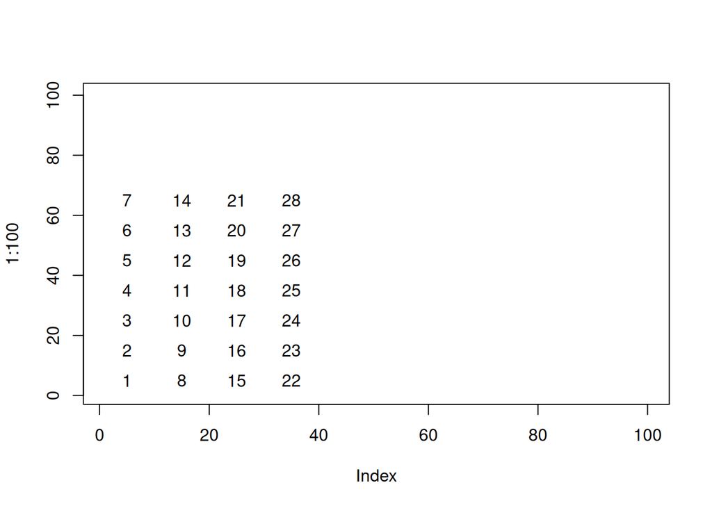

```
##
## RDt_s_> i<-.$plot=="Bunazaka"
##
## RDt_s_> text(.$x[i],.$y[i],.$subplot[i])
##
## RDt_s_> RData_subplot_xy()
## [1] "This is data !!"
```

```r
try(example('RData_subplot_xy', package = 'TateyamaVegetation', echo=TRUE, ask=FALSE), silent = TRUE)
```

## 25 `SpeciesNameCheck`

**Documentation:**

```
種の和名が植物目録floraに記載されているか確認します

Description:

     種の和名が植物目録floraに記載されているか確認します

Usage:

     SpeciesNameCheck(spj)

Arguments:

     spj: 種名(和名)のベクトル

Value:

     記載の有無、記載のない入力種名

Examples:

     SpeciesNameCheck(c("ブナ","スギ","クロベ"))
     d<-FieldNote_Arimine2019_raw
     head(d)
     spj<-d$種名
     SpeciesNameCheck(spj)
```

**Examples (from .Rd):**

```r
### Name: SpeciesNameCheck
### Title: 種の和名が植物目録floraに記載されているか確認します
### Aliases: SpeciesNameCheck

### ** Examples

SpeciesNameCheck(c("ブナ","スギ","クロベ"))
d<-FieldNote_Arimine2019_raw
head(d)
spj<-d$種名
SpeciesNameCheck(spj)
```

**Executed Example:**

```r
try(example('SpeciesNameCheck', package = 'TateyamaVegetation', echo=TRUE, ask=FALSE), silent = TRUE)
```

```
##
## SpcsNC> SpeciesNameCheck(c("ブナ","スギ","クロベ"))
## クロベ はリストにありません。
##  種名を修正するか、floraに新たな種を追加してください。
##
## SpcsNC> d<-FieldNote_Arimine2019_raw
##
## SpcsNC> head(d)
## # A tibble: 6 × 10
##   サブプロット 階層  種名           DK2000 被度2007 被度2013 被度2019 X        no   II_
##          <dbl> <chr> <chr>           <dbl>    <dbl>    <dbl>    <dbl> <lgl> <dbl> <dbl>
## 1            1 B2    アオダモ          0        1          1      1   NA        1   1
## 2            1 B2    イタヤカエデ      0.5      0.5        1      0.3 NA        6   0.5
## 3            1 B2    ウリハダカエデ    0       12          3      0.5 NA        7   5
## 4            1 B2    ウワミズザクラ    4        5          5      0.8 NA        8   4
## 5            1 B2    オオカメノキ      5       10          5     14   NA        9   5
## 6            1 B2    オオバクロモジ    5       18         15     10   NA       10   6
##
## SpcsNC> spj<-d$種名
##
## SpcsNC> SpeciesNameCheck(spj)
## オオバユキザサ メイゲツカエデ コイワカガミ ナライシダ イワガラミ ツタウルシ はリストにありません。
##  種名を修正するか、floraに新たな種を追加してください。
```

## 26 `SpeciesNameCorrect`

**Documentation:**

```
和名の置換 本調査の種和名はYList(米倉浩司・梶田忠
2007-)の第一和名に基づきます。
同種異名は本コマンドで置換表sp_excに基づき修正できます。

Description:

     和名の置換 本調査の種和名はYList(米倉浩司・梶田忠
     2007-)の第一和名に基づきます。
     同種異名は本コマンドで置換表sp_excに基づき修正できます。

Usage:

     SpeciesNameCorrect(spj)

Arguments:

     spj:

Examples:

     d<-FieldNote_Arimine2019_raw
     spj<-d$種名
     SpeciesNameCheck(spj)
     SpeciesNameCheck(SpeciesNameCorrect(spj))
```

**Examples (from .Rd):**

```r
### Name: SpeciesNameCorrect
### Title: 和名の置換 本調査の種和名はYList(米倉浩司・梶田忠
###   2007-)の第一和名に基づきます。
###   同種異名は本コマンドで置換表sp_excに基づき修正できます。
### Aliases: SpeciesNameCorrect

### ** Examples

d<-FieldNote_Arimine2019_raw
spj<-d$種名
SpeciesNameCheck(spj)
SpeciesNameCheck(SpeciesNameCorrect(spj))
```

**Executed Example:**

```r
try(example('SpeciesNameCorrect', package = 'TateyamaVegetation', echo=TRUE, ask=FALSE), silent = TRUE)
```

```
##
## SpcsNC> d<-FieldNote_Arimine2019_raw
##
## SpcsNC> spj<-d$種名
##
## SpcsNC> SpeciesNameCheck(spj)
## オオバユキザサ メイゲツカエデ コイワカガミ ナライシダ イワガラミ ツタウルシ はリストにありません。
##  種名を修正するか、floraに新たな種を追加してください。
##
## SpcsNC> SpeciesNameCheck(SpeciesNameCorrect(spj))
## イワガラミ ツタウルシ はリストにありません。
##  種名を修正するか、floraに新たな種を追加してください。
```

## 27 `TateyamaVegetationPlots`

**Documentation:**

```
data/ 立山植生モニタリング調査区一覧表

Description:

     data/ 立山植生モニタリング調査区一覧表

Usage:

     data(TateyamaVegetationPlots)

Format:

     An object of class `spec_tbl_df`.

Examples:

     TateyamaVegetationPlots
```

**Examples (from .Rd):**

```r
### Name: TateyamaVegetationPlots
### Title: data/ 立山植生モニタリング調査区一覧表
### Aliases: TateyamaVegetationPlots
### Keywords: datasets

### ** Examples

TateyamaVegetationPlots
```

**Executed Example:**

```r
try(example('TateyamaVegetationPlots', package = 'TateyamaVegetation', echo=TRUE, ask=FALSE), silent = TRUE)
```

```
##
## TtymVP> TateyamaVegetationPlots
## # A tibble: 27 × 12
##    プロット名       ...2  `[01] 美女平` `[02] ブナ坂` `[03] ブナ平` `[04] 上ノ小平` `[05] 弥陀ヶ原` `[06] 美松` `[07] 松尾峠` `[08] 鏡石` `[09] 浄土山` `[10] 有峰`
##    <chr>            <chr> <chr>         <chr>         <chr>         <chr>           <chr>           <chr>       <chr>         <chr>       <chr>         <chr>
##  1 旧名称           <NA>  A             B             E             H               D               F           C             G           I             J
##  2 緯度_wgs84       <NA>  36.582854     36.578568     36.580857     36.571317       36.5739972      36.570683   36.561895     36.582018   36.566646     36.496705
##  3 経度_wgs84       <NA>  137.466717    137.467562    137.47948     137.506773      137.554075      137.559582  137.552649    137.575497  137.605328    137.429293
##  4 平均標高(m)      <NA>  1040          1090          1190          1430            1890            1960        1970          2250        2830          1350
##  5 プロット(m)      <NA>  100*100       100*100       100*100       100*100         5*100           50*100      50*100        25*25       15*15         100*100
##  6 プロット面積(ha) <NA>  1             1             1             1               0.05            0.5         0.5           0.0625      0.0225        1
##  7 植生調査枠(m)    <NA>  50*50         40*70         50*50         50*50           5*100           50*50       100*50        25*25       15*15         50*50
##  8 サブプロット数   <NA>  10*10         10*10         10*10         10*10           5*5             10*10       10*10         5*5         3*3           10*10
##  9 サブプロット(m)  <NA>  25            28            25            25              20              25          50            25          25            25
## 10 平均気温(℃)      ※1    8.1           8.1           7.9           6.4             8.1             3.7         3.4           2           -0.9          6
## # ℹ 17 more rows
```

## 28 `VC`

**Documentation:**

```
data/ Vegetation chronosequence

Description:

     data/ Vegetation chronosequence

Usage:

     data(vv5)

Format:

     An object of class `tbl_df`.

Source:

     automatically generated skeleton

See Also:

     [VegetationChronologyTable()]

Examples:

     VC
     (d<- VC[["Arimine"]])
     nm<-names(d)
      gsub("Mean","m",nm)
      sptype
      d$sp
      d.<-cbind(
      d[,c("sp","Frequencydk01","Frequencyc02","Frequencyc03","Frequencyc04","Frequencyc05")],
      d[,c("FreqCodedk01","FreqCodec02","FreqCodec03","FreqCodec04","FreqCodec05")],
      d[,c("Meandk01","Meanc02","Meanc03","Meanc04","Meanc05")],
      d[,c("DominatIndexdk01dk","DominatIndexc02dk","DominatIndexc03dk","DominatIndexc04dk","DominatIndexc05dk")]
      )
      names(d.)<- c("sp",paste0("f",1:5),paste0("F",1:5),paste0("c",1:5),paste0("di",1:5))

      tibble(d.)
       d. %>%
         mutate()

      d %>% select(sp, starts_with("Meanc"))
```

**Examples (from .Rd):**

```r
### Name: VC
### Title: data/ Vegetation chronosequence
### Aliases: VC
### Keywords: datasets

### ** Examples

VC
(d<- VC[["Arimine"]])
nm<-names(d)
 gsub("Mean","m",nm)
 sptype
 d$sp
 d.<-cbind(
 d[,c("sp","Frequencydk01","Frequencyc02","Frequencyc03","Frequencyc04","Frequencyc05")],
 d[,c("FreqCodedk01","FreqCodec02","FreqCodec03","FreqCodec04","FreqCodec05")],
 d[,c("Meandk01","Meanc02","Meanc03","Meanc04","Meanc05")],
 d[,c("DominatIndexdk01dk","DominatIndexc02dk","DominatIndexc03dk","DominatIndexc04dk","DominatIndexc05dk")]
 )
 names(d.)<- c("sp",paste0("f",1:5),paste0("F",1:5),paste0("c",1:5),paste0("di",1:5))

 tibble(d.)
  d. %>%
    mutate()

 d %>% select(sp, starts_with("Meanc"))
```

**Executed Example:**

```r
try(example('VC', package = 'TateyamaVegetation', echo=TRUE, ask=FALSE), silent = TRUE)
```

```
##
## VC> VC
## $Bijodaira
## # A tibble: 137 × 41
##    sp     Meandk01 Frequencydk01 FreqCodedk01 DominatIndexdk01 Meandk01dk Frequencydk01dk FreqCodedk01dk DominatIndexdk01dk Meanc02 Frequencyc02 FreqCodec02 DominatIndexc02 Meanc02dk
##    <chr>     <dbl>         <dbl> <chr>                   <dbl>      <dbl>           <dbl> <chr>                       <dbl>   <dbl>        <dbl> <chr>                 <dbl>     <dbl>
##  1 アオダモ……     0.16         0.346 Ⅱ                        7.44       0.16           0.346 Ⅱ                            7.44    0.26        0.5   Ⅲ                     11.4       0.26
##  2 アカミノイ…     0.06         0.154 Ⅰ                        3.04       0.06           0.154 Ⅰ                            3.04    0.04        0.115 Ⅰ                      2.15      0.04
##  3 ウリハダカ…     0.76         0.538 Ⅲ                       20.2        0.76           0.538 Ⅲ                           20.2     1.14        0.577 Ⅲ                     25.6       0.78
##  4 ウワミズザ…     0.68         0.462 Ⅲ                       17.7        0.68           0.462 Ⅲ                           17.7     0.78        0.423 Ⅲ                     18.2       0.78
##  5 エゾアジサ…     0.28         0.115 Ⅰ                        5.68       0.28           0.115 Ⅰ                            5.68    0           0     -                      0         0
##  6 エゾユズリ…     0.16         0.154 Ⅰ                        4.96       0.16           0.154 Ⅰ                            4.96    0.16        0.115 Ⅰ                      4.30      0.16
##  7 オオカメノ…     3.64         1     Ⅴ                       60.3        3.64           1     Ⅴ                           60.3     6           1     Ⅴ                     77.5       3.56
##  8 オオバクロ…     3.08         0.962 Ⅴ                       54.4        3.08           0.962 Ⅴ                           54.4     4.68        0.962 Ⅴ                     67.1       3.04
##  9 コシアブラ…     0.54         0.654 Ⅳ                       18.8        0.54           0.654 Ⅳ                           18.8     0.78        0.846 Ⅴ                     25.7       0.78
## 10 コミネカエ…     0.38         0.538 Ⅲ                       14.3        0.38           0.538 Ⅲ                           14.3     0.34        0.538 Ⅲ                     13.5       0.34
## # ℹ 127 more rows
## # ℹ 27 more variables: Frequencyc02dk <dbl>, FreqCodec02dk <chr>, DominatIndexc02dk <dbl>, Meanc03 <dbl>, Frequencyc03 <dbl>, FreqCodec03 <chr>, DominatIndexc03 <dbl>,
## #   Meanc03dk <dbl>, Frequencyc03dk <dbl>, FreqCodec03dk <chr>, DominatIndexc03dk <dbl>, Meanc04 <dbl>, Frequencyc04 <dbl>, FreqCodec04 <chr>, DominatIndexc04 <dbl>,
## #   Meanc04dk <dbl>, Frequencyc04dk <dbl>, FreqCodec04dk <chr>, DominatIndexc04dk <dbl>, Meanc05 <dbl>, Frequencyc05 <dbl>, FreqCodec05 <chr>, DominatIndexc05 <dbl>,
## #   Meanc05dk <dbl>, Frequencyc05dk <dbl>, FreqCodec05dk <chr>, DominatIndexc05dk <dbl>
##
## $Bunazaka
## # A tibble: 89 × 41
##    sp     Meandk01 Frequencydk01 FreqCodedk01 DominatIndexdk01 Meandk01dk Frequencydk01dk FreqCodedk01dk DominatIndexdk01dk Meanc02 Frequencyc02 FreqCodec02 DominatIndexc02 Meanc02dk
##    <chr>     <dbl>         <dbl> <chr>                   <dbl>      <dbl>           <dbl> <chr>                       <dbl>   <dbl>        <dbl> <chr>                 <dbl>     <dbl>
##  1 アオダモ……   0.321          0.586 Ⅲ                       13.7      0.321            0.586 Ⅲ                           13.7   0.5          0.621  Ⅳ                     17.6     0.5
##  2 アクシバ……   0.161          0.345 Ⅱ                        7.44     0.161            0.345 Ⅱ                            7.44  0.232        0.448  Ⅲ                     10.2     0.232
##  3 ウリハダカ…   0.339          0.690 Ⅳ                       15.3      0.339            0.690 Ⅳ                           15.3   0.339        0.690  Ⅳ                     15.3     0.339
##  4 ウワミズザ…   0.161          0.310 Ⅱ                        7.06     0.161            0.310 Ⅱ                            7.06  0.25         0.448  Ⅲ                     10.6     0.25
##  5 エゾユズリ…   4.04           1     Ⅴ                       63.5      4.04             1     Ⅴ                           63.5   6.61         1      Ⅴ                     81.3     3.86
##  6 オオカメノ…   3.95           1     Ⅴ                       62.8      3.95             1     Ⅴ                           62.8   6.62         0.966  Ⅴ                     80.0     3.88
##  7 オオバクロ…   3.71           0.931 Ⅴ                       58.8      3.71             0.931 Ⅴ                           58.8   6.46         0.897  Ⅴ                     76.1     3.64
##  8 コシアブラ…   0.321          0.655 Ⅳ                       14.5      0.321            0.655 Ⅳ                           14.5   0.464        0.759  Ⅳ                     18.8     0.464
##  9 コミネカエ…   0.0357         0.103 Ⅰ                        1.92     0.0357           0.103 Ⅰ                            1.92  0.0179       0.0690 Ⅰ                      1.11    0.0179
## 10 サワフタギ…   0.518          0.345 Ⅱ                       13.4      0.518            0.345 Ⅱ                           13.4   0.446        0.345  Ⅱ                     12.4     0.446
## # ℹ 79 more rows
## # ℹ 27 more variables: Frequencyc02dk <dbl>, FreqCodec02dk <chr>, DominatIndexc02dk <dbl>, Meanc03 <dbl>, Frequencyc03 <dbl>, FreqCodec03 <chr>, DominatIndexc03 <dbl>,
## #   Meanc03dk <dbl>, Frequencyc03dk <dbl>, FreqCodec03dk <chr>, DominatIndexc03dk <dbl>, Meanc04 <dbl>, Frequencyc04 <dbl>, FreqCodec04 <chr>, DominatIndexc04 <dbl>,
## #   Meanc04dk <dbl>, Frequencyc04dk <dbl>, FreqCodec04dk <chr>, DominatIndexc04dk <dbl>, Meanc05 <dbl>, Frequencyc05 <dbl>, FreqCodec05 <chr>, DominatIndexc05 <dbl>,
```

[output cut: 307 more lines]

```
## VC>  d %>% select(sp, starts_with("Meanc"))
## # A tibble: 83 × 9
##    sp             Meanc02 Meanc02dk Meanc03 Meanc03dk Meanc04 Meanc04dk Meanc05 Meanc05dk
##    <chr>            <dbl>     <dbl>   <dbl>     <dbl>   <dbl>     <dbl>   <dbl>     <dbl>
##  1 アオダモ          0.94      0.86   0.832      0.86   1          1.04       0         0
##  2 イタヤカエデ      0.26      0.26   0.316      0.4    0.192      0.28       0         0
##  3 ウリハダカエデ    4         2.88   2.29       1.68   2.94       2.08       0         0
##  4 ウワミズザクラ    2.02      1.66   1.96       1.76   2.44       2.1        0         0
##  5 オオカメノキ     13.8       4.84  15.9        5.08  16.6        5.2        0         0
##  6 オオバクロモジ    6.48      3.76   6.08       3.2    9.52       4.04       0         0
##  7 コシアブラ        0.44      0.44   1.10       1.08   2.24       1.64       0         0
##  8 コマユミ          0.1       0.1    0.172      0.22   0.208      0.3        0         0
##  9 サワフタギ        1.98      1.14   1.2        0.88   1.6        1.06       0         0
## 10 タムシバ          0.02      0.02   0.14       0.14   0.188      0.2        0         0
## # ℹ 73 more rows
```

## 29 `VCrepo`

**Documentation:**

```
data/ Vegetation chronosequence summary

Description:

     data/ Vegetation chronosequence summary

     data/ Vegetation chronosequence summary (data frame)

Usage:

     data(VCrepo)

     data(vc5)

Format:

     A list of the objects of class `tbl_df`.

     A `tbl_df`.

Source:

     VCrepo

See Also:

     [VegetationChronologyTable()]

Examples:

     VCrepo
     VCrepo
     vc5
```

**Examples (from .Rd):**

```r
### Name: VCrepo
### Title: data/ Vegetation chronosequence summary
### Aliases: VCrepo vc5
### Keywords: datasets

### ** Examples

VCrepo
VCrepo
vc5
```

**Executed Example:**

```r
try(example('VCrepo', package = 'TateyamaVegetation', echo=TRUE, ask=FALSE), silent = TRUE)
```

```
##
## VCrepo> VCrepo
## $Bijodaira
## # A tibble: 137 × 24
##    layer sp               form     f1     f2     f3     f4    f5 F1    F2    F3    F4    F5       c1    c2    c3     c4     c5   di1   di2   di3   di4   di5   cal
##    <chr> <chr>            <chr> <dbl>  <dbl>  <dbl>  <dbl> <dbl> <chr> <chr> <chr> <chr> <chr> <dbl> <dbl> <dbl>  <dbl>  <dbl> <dbl> <dbl> <dbl> <dbl> <dbl> <dbl>
##  1 B2    アオダモ         bl    0.346 0.5    0.808  0.846  0.885 Ⅱ     Ⅲ     Ⅴ     Ⅴ     Ⅴ      0.16  0.26  0.56  0.66   0.716  7.44 11.4  21.3  24.0  25.9      1
##  2 B2    アカミノイヌツゲ bs    0.154 0.115  0.0769 0.0769 0.115 Ⅰ     Ⅰ     Ⅰ     Ⅰ     Ⅰ      0.06  0.04  0.08  0.04   0.06   3.04  2.15  2.48  1.75  2.63     1
##  3 B2    アクシバ         bs    0.154 0.0769 0.231  0.192  0.346 Ⅰ     Ⅰ     Ⅱ     Ⅰ     Ⅱ      0.08  0.02  0.22  0.112  0.176  3.51  1.24  7.13  5.19  8.73     1
##  4 B2    イタヤカエデ     bl    0     0      0.0769 0.0769 0.115 -     -     Ⅰ     Ⅰ     Ⅰ      0     0     0.02  0.02   0.024  0     0     1.24  1.24  2.15     0
##  5 B2    ウリハダカエデ   bl    0.538 0.577  0.885  0.923  1     Ⅲ     Ⅲ     Ⅴ     Ⅴ     Ⅴ      0.76  1.14  1.46  1.07   1.19  20.2  21.2  33.9  31.3  33.2      1
##  6 B2    ウワミズザクラ   bl    0.462 0.423  0.577  0.731  0.5   Ⅲ     Ⅲ     Ⅲ     Ⅳ     Ⅲ      0.68  0.78  0.62  0.636  0.432 17.7  18.2  18.3  22.6  14.5      1
##  7 B2    エゾアジサイ     bs    0.115 0      0      0      0     Ⅰ     -     -     -     -      0.28  0     0     0      0      5.68  0     0     0     0        0
##  8 B2    エゾユズリハ     bs    0.154 0.115  0.192  0.115  0.231 Ⅰ     Ⅰ     Ⅰ     Ⅰ     Ⅱ      0.16  0.16  0.1   0.036  0.068  4.96  4.30  4.39  2.15  4.80     1
##  9 B2    オオカメノキ     bs    1     1      1      1      1     Ⅴ     Ⅴ     Ⅴ     Ⅴ     Ⅴ      3.64  6     8.84 10.7   12.0   60.3  59.7  65.7  66.9  67.5      1
## 10 B2    オオバクロモジ   bs    0.962 0.962  1      0.962  1     Ⅴ     Ⅴ     Ⅴ     Ⅴ     Ⅴ      3.08  4.68  6.8   4.95   4.24  54.4  54.1  62.9  54.1  55.1      1
## # ℹ 127 more rows
##
## $Bunazaka
## # A tibble: 89 × 24
##    layer sp               form     f1     f2     f3     f4     f5 F1    F2    F3    F4    F5       c1     c2      c3      c4      c5   di1   di2   di3   di4   di5   cal
##    <chr> <chr>            <chr> <dbl>  <dbl>  <dbl>  <dbl>  <dbl> <chr> <chr> <chr> <chr> <chr> <dbl>  <dbl>   <dbl>   <dbl>   <dbl> <dbl> <dbl> <dbl> <dbl> <dbl> <dbl>
##  1 B2    アオダモ         bl    0.586 0.621  0.759  0.724  0.793  Ⅲ     Ⅳ     Ⅳ     Ⅳ     Ⅳ     0.321 0.5     0.857   1.16    1.63   13.7  17.6  25.0  27.9  31.5      1
##  2 B2    アカミノイヌツゲ bs    0     0      0.138  0.0690 0.138  -     -     Ⅰ     Ⅰ     Ⅰ     0     0       0.0536  0.0357  0.0464  0     0     2.72  1.57  3.14     0
##  3 B2    アクシバ         bs    0.345 0.448  0.517  0.552  0.517  Ⅱ     Ⅲ     Ⅲ     Ⅲ     Ⅲ     0.161 0.232   0.321   0.239   0.504   7.44 10.2  12.9  13.3  16.1      1
##  4 B2    ウスノキ         bs    0     0      0.0690 0.0690 0.0690 -     -     Ⅰ     Ⅰ     Ⅰ     0     0       0.0357  0.0179  0.0536  0     0     1.57  1.11  1.57     0
##  5 B2    ウリハダカエデ   bl    0.690 0.690  0.759  0.828  0.862  Ⅳ     Ⅳ     Ⅳ     Ⅴ     Ⅴ     0.339 0.339   0.464   0.45    0.426  15.3  15.3  18.8  20.3  21.8      1
##  6 B2    ウワミズザクラ   bl    0.310 0.448  0.862  0.862  0.897  Ⅱ     Ⅲ     Ⅴ     Ⅴ     Ⅴ     0.161 0.25    0.661   0.693   1.02    7.06 10.6  23.9  25.1  28.9      1
##  7 B2    エゾユズリハ     bs    1     1      1      1      0.897  Ⅴ     Ⅴ     Ⅴ     Ⅴ     Ⅴ     4.04  6.61    3.05    2.01    1.87   63.5  62.1  48.7  42.3  37.7      1
##  8 B2    オオカメノキ     bs    1     0.966  1      1      1      Ⅴ     Ⅴ     Ⅴ     Ⅴ     Ⅴ     3.95  6.62   11.5    11.0    11.2    62.8  61.2  66.5  67.1  67.1      1
##  9 B2    オオバクロモジ   bs    0.931 0.897  1      1      1      Ⅴ     Ⅴ     Ⅴ     Ⅴ     Ⅴ     3.71  6.46    7.07    6.64    8.07   58.8  57.1  63.2  62.1  62.7      1
## 10 B2    クマイチゴ       bs    0     0.0690 0      0      0      -     Ⅰ     -     -     -     0     0.0179  0       0       0       0     1.11  0     0     0        0
## # ℹ 79 more rows
##
## $Bunadaira
## # A tibble: 77 × 24
##    layer sp               form     f1     f2    f3    f4     f5 F1    F2    F3    F4    F5       c1    c2     c3     c4     c5   di1   di2   di3   di4   di5   cal
##    <chr> <chr>            <chr> <dbl>  <dbl> <dbl> <dbl>  <dbl> <chr> <chr> <chr> <chr> <chr> <dbl> <dbl>  <dbl>  <dbl>  <dbl> <dbl> <dbl> <dbl> <dbl> <dbl> <dbl>
##  1 B2    アオダモ         bl    0     0      0     0     0.0769 -     -     -     -     Ⅰ      0     0     0      0      0.004  0     0     0     0     1.24     0
##  2 B2    アカミノイヌツゲ bs    0     0.0769 0     0     0.0769 -     Ⅰ     -     -     Ⅰ      0     0.02  0      0      0.06   0     1.24  0     0     1.75     0
```

[output cut: 299 more lines]

```
## VCrepo> vc5
## # A tibble: 764 × 25
##    plot      layer sp               form     f1     f2     f3     f4    f5 F1    F2    F3    F4    F5       c1    c2    c3     c4     c5   di1   di2   di3   di4   di5   cal
##    <chr>     <chr> <chr>            <chr> <dbl>  <dbl>  <dbl>  <dbl> <dbl> <chr> <chr> <chr> <chr> <chr> <dbl> <dbl> <dbl>  <dbl>  <dbl> <dbl> <dbl> <dbl> <dbl> <dbl> <dbl>
##  1 Bijodaira B2    アオダモ         bl    0.346 0.5    0.808  0.846  0.885 Ⅱ     Ⅲ     Ⅴ     Ⅴ     Ⅴ      0.16  0.26  0.56  0.66   0.716  7.44 11.4  21.3  24.0  25.9      1
##  2 Bijodaira B2    アカミノイヌツゲ bs    0.154 0.115  0.0769 0.0769 0.115 Ⅰ     Ⅰ     Ⅰ     Ⅰ     Ⅰ      0.06  0.04  0.08  0.04   0.06   3.04  2.15  2.48  1.75  2.63     1
##  3 Bijodaira B2    アクシバ         bs    0.154 0.0769 0.231  0.192  0.346 Ⅰ     Ⅰ     Ⅱ     Ⅰ     Ⅱ      0.08  0.02  0.22  0.112  0.176  3.51  1.24  7.13  5.19  8.73     1
##  4 Bijodaira B2    イタヤカエデ     bl    0     0      0.0769 0.0769 0.115 -     -     Ⅰ     Ⅰ     Ⅰ      0     0     0.02  0.02   0.024  0     0     1.24  1.24  2.15     0
##  5 Bijodaira B2    ウリハダカエデ   bl    0.538 0.577  0.885  0.923  1     Ⅲ     Ⅲ     Ⅴ     Ⅴ     Ⅴ      0.76  1.14  1.46  1.07   1.19  20.2  21.2  33.9  31.3  33.2      1
##  6 Bijodaira B2    ウワミズザクラ   bl    0.462 0.423  0.577  0.731  0.5   Ⅲ     Ⅲ     Ⅲ     Ⅳ     Ⅲ      0.68  0.78  0.62  0.636  0.432 17.7  18.2  18.3  22.6  14.5      1
##  7 Bijodaira B2    エゾアジサイ     bs    0.115 0      0      0      0     Ⅰ     -     -     -     -      0.28  0     0     0      0      5.68  0     0     0     0        0
##  8 Bijodaira B2    エゾユズリハ     bs    0.154 0.115  0.192  0.115  0.231 Ⅰ     Ⅰ     Ⅰ     Ⅰ     Ⅱ      0.16  0.16  0.1   0.036  0.068  4.96  4.30  4.39  2.15  4.80     1
##  9 Bijodaira B2    オオカメノキ     bs    1     1      1      1      1     Ⅴ     Ⅴ     Ⅴ     Ⅴ     Ⅴ      3.64  6     8.84 10.7   12.0   60.3  59.7  65.7  66.9  67.5      1
## 10 Bijodaira B2    オオバクロモジ   bs    0.962 0.962  1      0.962  1     Ⅴ     Ⅴ     Ⅴ     Ⅴ     Ⅴ      3.08  4.68  6.8   4.95   4.24  54.4  54.1  62.9  54.1  55.1      1
## # ℹ 754 more rows
```

## 30 `VT`

**Documentation:**

```
data/ 植生調査票(2020-2025) VT Vegtaion cross table for the period V
(2020-2025)

Description:

     data/ 植生調査票(2020-2025) VT Vegtaion cross table for the period
     V (2020-2025)

Usage:

     data(VT)

Format:

     An object of class `list` of `tbl_df`.

Source:

     automatically generated skeleton

See Also:

     [VTdk]

Examples:

     names(VT)
      VT[["Arimine_c04"]]
      VTdk[["Arimine_c04"]]
```

**Examples (from .Rd):**

```r
### Name: VT
### Title: data/ 植生調査票(2020-2025) VT Vegtaion cross table for the
###   period V (2020-2025)
### Aliases: VT
### Keywords: datasets

### ** Examples

names(VT)
 VT[["Arimine_c04"]]
 VTdk[["Arimine_c04"]]
```

**Executed Example:**

```r
try(example('VT', package = 'TateyamaVegetation', echo=TRUE, ask=FALSE), silent = TRUE)
```

```
##
## VT> names(VT)
##  [1] "Bijodaira_dk01"     "Bijodaira_c02"      "Bijodaira_c03"      "Bijodaira_c04"      "Bijodaira_c05"      "Bunazaka_dk01"      "Bunazaka_c02"       "Bunazaka_c03"
##  [9] "Bunazaka_c04"       "Bunazaka_c05"       "Bunadaira_dk01"     "Bunadaira_c02"      "Bunadaira_c03"      "Bunadaira_c04"      "Bunadaira_c05"      "Kaminokodaira_dk01"
## [17] "Kaminokodaira_c02"  "Kaminokodaira_c03"  "Kaminokodaira_c04"  "Kaminokodaira_c05"  "Midagahara_dk01"    "Midagahara_c02"     "Midagahara_c03"     "Midagahara_c04"
## [25] "Midagahara_c05"     "Mimatsu_dk01"       "Mimatsu_c02"        "Mimatsu_c03"        "Mimatsu_c04"        "Mimatsu_c05"        "Matsuotoge_dk01"    "Matsuotoge_c02"
## [33] "Matsuotoge_c03"     "Matsuotoge_c04"     "Matsuotoge_c05"     "Kagamiishi_dk01"    "Kagamiishi_c02"     "Kagamiishi_c03"     "Kagamiishi_c04"     "Kagamiishi_c05"
## [41] "Joudosan_dk01"      "Joudosan_c02"       "Joudosan_c03"       "Joudosan_c04"       "Joudosan_c05"       "Arimine_dk01"       "Arimine_c02"        "Arimine_c03"
## [49] "Arimine_c04"        "Arimine_c05"
##
## VT>  VT[["Arimine_c04"]]
## # A tibble: 83 × 30
##    sp             `1`   `2`   `3`   `4`   `5`   `6`   `7`   `8`   `9`  `10`  `11`  `12`  `13`  `14`  `15`  `16`  `17`  `18`  `19`  `20`  `21`  `22`  `23`  `24`  `25`   Mean Frequency
##    <chr>        <dbl> <dbl> <dbl> <dbl> <dbl> <dbl> <dbl> <dbl> <dbl> <dbl> <dbl> <dbl> <dbl> <dbl> <dbl> <dbl> <dbl> <dbl> <dbl> <dbl> <dbl> <dbl> <dbl> <dbl> <dbl>  <dbl>     <dbl>
##  1 アオダモ       1     3.5   0.5   3     0     0     1     1     0     0     1     3     2     0     0.1   2     5       1     0   0.2   0.2   0.1   0.2   0.1   0.1  1         0.769
##  2 イタヤカエデ   0.3   0     0     0     0.5   0.5   0.5   0     0     0     0.5   0.5   0.5   0     0.2   0.1   0.5     0     0   0     0.2   0.1   0.1   0     0.3  0.192     0.577
##  3 ウリハダカエデ……   0.5  13     1.5   2    10     1     6     4     1     2     1     2     1     5     2     0.2   3.4     6     4   0.6   0.5   5     1     0.5   0.2  2.94      1
##  4 ウワミズザクラ……   0.8   3     3     3     4     2     4     0.5   2     5     0     1     2     2     3     0     1.5     5     2   1     6     0.1   4     5     1    2.44      0.923
##  5 オオカメノキ  14    37    30    20    15    25    23    35    21     4    20    20    20    10     4    13    17      14    11  10    18    15     5     6     7   16.6       1
##  6 オオバクロモジ……  10    25    20     4     6    18    15    19     7     7    13     8    25     3     3     4     6      13    12   2     2     6     6     3     1    9.52      1
##  7 コシアブラ     4     0     5.5   1.5   0.7   0     1     4     0     2     3     4    14     1     0.5   0.1   1       3     4   0.5   0.2   0.1   5     0.5   0.3  2.24      0.885
##  8 コマユミ       0.1   0.5   0     0.5   0.5   0.5   0.5   0     0.5   0     0.2   0.2   0.2   0.5   0.2   0.2   0       0     0   0.1   0.5   0     0     0     0    0.208     0.615
##  9 サワフタギ     2     0     0     0     0     0     0     1.5   7     0.5   0     0     1     0     0     0     0       0     7   4     0     0     5     2    10    1.6       0.423
## 10 タムシバ       3     0     0     0     0     0     0     0.5   0.5   0     0     0     0     0.5   0     0     0       0     0   0.2   0     0     0     0     0    0.188     0.231
## # ℹ 73 more rows
## # ℹ 2 more variables: FreqCode <chr>, DominatIndex <dbl>
##
## VT>  VTdk[["Arimine_c04"]]
## # A tibble: 83 × 30
##    sp              `1`   `2`   `3`   `4`   `5`   `6`   `7`   `8`   `9`  `10`  `11`  `12`  `13`  `14`  `15`  `16`  `17`  `18`  `19`  `20`  `21`  `22`  `23`  `24`  `25`  Mean Frequency
##    <chr>         <dbl> <dbl> <dbl> <dbl> <dbl> <dbl> <dbl> <dbl> <dbl> <dbl> <dbl> <dbl> <dbl> <dbl> <dbl> <dbl> <dbl> <dbl> <dbl> <dbl> <dbl> <dbl> <dbl> <dbl> <dbl> <dbl>     <dbl>
##  1 アオダモ        1     3     0.5   3     0     0     1     1     0     0     1     3     2     0     0.5   2     4       1     0   0.5   0.5   0.5   0.5   0.5   0.5  1.04     0.769
##  2 イタヤカエデ    0.5   0     0     0     0.5   0.5   0.5   0     0     0     0.5   0.5   0.5   0     0.5   0.5   0.5     0     0   0     0.5   0.5   0.5   0     0.5  0.28     0.577
##  3 ウリハダカエデ……   0.5   5     1     2     5     1     4     3     1     2     1     2     1     4     2     0.5   3       4     3   0.5   0.5   4     1     0.5   0.5  2.08     1
##  4 ウワミズザクラ……   0.5   3     3     3     3     2     3     0.5   2     4     0     1     2     2     3     0     1       4     2   1     4     0.5   3     4     1    2.1      0.923
##  5 オオカメノキ    5     7     6     6     5     6     6     7     6     3     6     6     6     5     3     5     5       5     5   5     5     5     4     4     4    5.2      1
##  6 オオバクロモジ……   5     6     6     3     4     5     5     5     4     4     5     4     6     3     3     3     4       5     5   2     2     4     4     3     1    4.04     1
##  7 コシアブラ      3     0     4     1     0.5   0     1     3     0     2     3     3     5     1     0.5   0.5   1       3     3   0.5   0.5   0.5   4     0.5   0.5  1.64     0.885
##  8 コマユミ        0.5   0.5   0     0.5   0.5   0.5   0.5   0     0.5   0     0.5   0.5   0.5   0.5   0.5   0.5   0       0     0   0.5   0.5   0     0     0     0    0.3      0.615
##  9 サワフタギ      2     0     0     0     0     0     0     1     4     0.5   0     0     1     0     0     0     0       0     4   3     0     0     4     2     5    1.06     0.423
## 10 タムシバ        3     0     0     0     0     0     0     0.5   0.5   0     0     0     0     0.5   0     0     0       0     0   0.5   0     0     0     0     0    0.2      0.231
## # ℹ 73 more rows
## # ℹ 2 more variables: FreqCode <chr>, DominatIndex <dbl>
```

## 31 `VegetationChronologyTable`

**Documentation:**

```
植生経年変化表　(粗表)

Description:

     植生経年変化表　(粗表)

Usage:

     VegetationChronologyTable(VT = VT, VTdk = VTdk)

Arguments:

    VTdk:

Examples:

     VC<-VegetationChronologyTable(VT=VT,VTdk=VTdk)
     # usethis::use_data(VC,overwrite = TRUE)
     VC$Arimine
```

**Examples (from .Rd):**

```r
### Name: VegetationChronologyTable
### Title: 植生経年変化表　(粗表)
### Aliases: VegetationChronologyTable

### ** Examples


VC<-VegetationChronologyTable(VT=VT,VTdk=VTdk)
# usethis::use_data(VC,overwrite = TRUE)
VC$Arimine
```

**Executed Example:**

```r
try(example('VegetationChronologyTable', package = 'TateyamaVegetation', echo=TRUE, ask=FALSE), silent = TRUE)
```

```
##
## VgttCT> VC<-VegetationChronologyTable(VT=VT,VTdk=VTdk)
## [1] "Bijodaira_dk01"
## [1] "Bijodaira_c02"
## [1] "Bijodaira_c03"
## [1] "Bijodaira_c04"
## [1] "Bijodaira_c05"
## [1] "Bunazaka_dk01"
## [1] "Bunazaka_c02"
## [1] "Bunazaka_c03"
## [1] "Bunazaka_c04"
## [1] "Bunazaka_c05"
## [1] "Bunadaira_dk01"
## [1] "Bunadaira_c02"
## [1] "Bunadaira_c03"
```

[output cut: 58 more lines]

## 32 `VegetationChronologyTable_report`

**Documentation:**

```
報告書用植生経年変化表

Description:

     報告書用植生経年変化表

Usage:

     VegetationChronologyTable_report(plot_name = "Arimine")

Arguments:

plot_name:

Examples:

     VegetationChronologyTable_report("Arimine")
     VCrepo<-lapply(plt$plot_name,VegetationChronologyTable_report)
     names(VCrepo)<-plt$plot_name

     VCrepo[["Kagamiishi"]]

     # usethis::use_data(VCrepo,overwrite = TRUE)
```

**Examples (from .Rd):**

```r
### Name: VegetationChronologyTable_report
### Title: 報告書用植生経年変化表
### Aliases: VegetationChronologyTable_report

### ** Examples


VegetationChronologyTable_report("Arimine")
VCrepo<-lapply(plt$plot_name,VegetationChronologyTable_report)
names(VCrepo)<-plt$plot_name

VCrepo[["Kagamiishi"]]

# usethis::use_data(VCrepo,overwrite = TRUE)
```

**Executed Example:**

```r
try(example('VegetationChronologyTable_report', package = 'TateyamaVegetation', echo=TRUE, ask=FALSE), silent = TRUE)
```

```
##
## VgtCT_> VegetationChronologyTable_report("Arimine")
## # A tibble: 83 × 24
##    layer sp                 form      f1     f2     f3     f4    f5 F1    F2    F3    F4    F5       c1    c2     c3     c4    c5   di1   di2   di3   di4   di5   cal
##    <chr> <chr>              <chr>  <dbl>  <dbl>  <dbl>  <dbl> <dbl> <chr> <chr> <chr> <chr> <chr> <dbl> <dbl>  <dbl>  <dbl> <dbl> <dbl> <dbl> <dbl> <dbl> <dbl> <dbl>
##  1 B2    アオダモ           bl    0.0769 0.692  0.885  0.769      0 Ⅰ     Ⅳ     Ⅴ     Ⅳ     -      0.02  0.94  0.832  1         0  1.24 24.4  27.6  28.3      0     0
##  2 B2    アクシバ           bs    0      0      0.0769 0.0769     0 -     -     Ⅰ     Ⅰ     -      0     0     0.04   0.08      0  0     0     1.75  2.48     0     0
##  3 B2    イタヤカエデ       bl    0.231  0.423  0.692  0.577      0 Ⅱ     Ⅲ     Ⅳ     Ⅲ     -      0.12  0.26  0.316  0.192     0  5.26 10.5  16.6  12.7      0     0
##  4 B2    ウリハダカエデ     bl    0.462  0.923  0.923  1          0 Ⅲ     Ⅴ     Ⅴ     Ⅴ     -      0.22  4     2.29   2.94      0 10.1  51.6  39.4  45.6      0     0
##  5 B2    ウワミズザクラ     bl    0.769  0.654  0.808  0.923      0 Ⅳ     Ⅳ     Ⅴ     Ⅴ     -      2.76  2.02  1.96   2.44      0 46.1  32.9  37.7  44.0      0     0
##  6 B2    エゾユズリハ       bs    0.0769 0.0769 0.115  0.0769     0 Ⅰ     Ⅰ     Ⅰ     Ⅰ     -      0.02  0.02  0.08   0.08      0  1.24  1.24  3.04  2.48     0     0
##  7 B2    オオイタヤメイゲツ bl    0      0      0.154  0          0 -     -     Ⅰ     -     -      0     0     0.28   0         0  0     0     6.08  0        0     0
##  8 B2    オオカメノキ       bs    1      0.962  1      1          0 Ⅴ     Ⅴ     Ⅴ     Ⅴ     -      5.24 13.8  15.9   16.6       0 72.4  68.2  71.3  72.1      0     0
##  9 B2    オオバクロモジ     bs    0.962  0.962  1      1          0 Ⅴ     Ⅴ     Ⅴ     Ⅴ     -      4     6.48  6.08   9.52      0 62.0  60.1  56.6  63.6      0     0
## 10 B2    クサアジサイ       bs    0.115  0.154  0.0769 0          0 Ⅰ     Ⅰ     Ⅰ     -     -      0.06  0.56  0.02   0         0  2.63  7.44  1.24  0        0     0
## # ℹ 73 more rows
##
## VgtCT_> VCrepo<-lapply(plt$plot_name,VegetationChronologyTable_report)
##
## VgtCT_> names(VCrepo)<-plt$plot_name
##
## VgtCT_> VCrepo[["Kagamiishi"]]
## # A tibble: 40 × 24
##    layer sp                 form     f1    f2    f3     f4     f5 F1    F2    F3    F4    F5       c1     c2     c3     c4     c5   di1   di2   di3   di4   di5   cal
##    <chr> <chr>              <chr> <dbl> <dbl> <dbl>  <dbl>  <dbl> <chr> <chr> <chr> <chr> <chr> <dbl>  <dbl>  <dbl>  <dbl>  <dbl> <dbl> <dbl> <dbl> <dbl> <dbl> <dbl>
##  1 B2    アカミノイヌツゲ   bs    0.115 0.154 0.269 0.154  0.154  Ⅰ     Ⅰ     Ⅱ     Ⅰ     Ⅰ      0.1   0.128  0.2    0.26   0.104  3.40  4.96  8.04  5.82  4.30     1
##  2 B2    ウスノキ           bs    0     0     0     0.0769 0.0769 -     -     -     Ⅰ     Ⅰ      0     0      0      0.004  0.004  0     0     0     1.24  1.24     0
##  3 B2    ウラジロナナカマド bs    0     0     0.192 0.231  0.308  -     -     Ⅰ     Ⅱ     Ⅱ      0     0      0.76   1.36   1.62   0     0     9.20 12.2  16.3      0
##  4 B2    オオシラビソ       cl    0.923 0.846 0.923 0.923  0.962  Ⅴ     Ⅴ     Ⅴ     Ⅴ     Ⅴ      4.56 16.7   13.4   13.6   12.6   64.9  60.7  62.0  62.1  60.3      1
##  5 B2    オオバスノキ       bs    0.731 0.692 0.846 0.885  0.885  Ⅳ     Ⅳ     Ⅴ     Ⅴ     Ⅴ      1.44  2.17   2.47   3.62   3.27  32.4  31.8  39.9  43.9  44.3      1
##  6 B2    クロウスゴ         bs    0.846 0.885 0.923 0.962  0.962  Ⅴ     Ⅴ     Ⅴ     Ⅴ     Ⅴ      2.42  2.90   2.57   2.97   1.99  45.3  45.7  44.2  45.1  42.7      1
##  7 B2    コヨウラクツツジ   bs    0.423 0.615 0.5   0.577  0.538  Ⅲ     Ⅳ     Ⅲ     Ⅲ     Ⅲ      0.44  0.292  0.516  0.644  0.776 13.6  16.8  16.4  19.2  20.2      1
##  8 B2    ナナカマド         bs    0.577 0.577 0.577 0.615  0.615  Ⅲ     Ⅲ     Ⅲ     Ⅳ     Ⅳ      2.28  5.72   7.68   7.44   5.00  36.3  36.3  37.5  40.3  35.6      1
##  9 B2    ハイマツ           cs    0.962 0.962 0.923 0.885  0.923  Ⅴ     Ⅴ     Ⅴ     Ⅴ     Ⅴ      6.12 30.2   23.6   20.5   23.3   76.7  76.5  70.3  66.5  71.4      1
## 10 B2    ハクサンシャクナゲ bs    0.5   0.577 0.538 0.692  0.692  Ⅲ     Ⅲ     Ⅲ     Ⅳ     Ⅳ      0.46  0.504  0.352  0.6    0.568 15.2  18.6  15.7  21.0  20.7      1
## # ℹ 30 more rows
##
## VgtCT_> # usethis::use_data(VCrepo,overwrite = TRUE)
## VgtCT_>
## VgtCT_>
## VgtCT_>
```

## 33 `VegetationFloraCode`

**Documentation:**

```
植物目録の各調査区における植生被度分布コードの作成

Description:

     植物目録の各調査区における植生被度分布コードの作成

Usage:

     VegetationFloraCode(cod = 1:10)

Arguments:

     cod:

Examples:

     VegetationFloraCode(1:10)
```

**Examples (from .Rd):**

```r
### Name: VegetationFloraCode
### Title: 植物目録の各調査区における植生被度分布コードの作成
### Aliases: VegetationFloraCode

### ** Examples


VegetationFloraCode(1:10)
```

**Executed Example:**

```r
try(example('VegetationFloraCode', package = 'TateyamaVegetation', echo=TRUE, ask=FALSE), silent = TRUE)
```

```
##
## VgttFC> VegetationFloraCode(1:10)
## [1] "1234-5-6789-A"
```

## 34 `VegetationFloraMatrix`

**Documentation:**

```
植生調査　調査区-出現種　出現頻度行列の作成 VCrepoより集計　10はAに変換

Description:

     植生調査　調査区-出現種　出現頻度行列の作成
     VCrepoより集計　10はAに変換

Usage:

     VegetationFloraMatrix(d = VCrepo)

Arguments:

       d:

Examples:

     m<-VegetationFloraMatrix(VCrepo)
     head(m)
     sp<-names(m)[-1]
     vc<-c(); for( i in sp)vc<-c(vc,VegetationFloraCode(cod=m[[i]]))
      vegetation_code<-data.frame(sp,vegetation_code=vc)
      # usethis::use_data(vegetation_code)
```

**Examples (from .Rd):**

```r
### Name: VegetationFloraMatrix
### Title: 植生調査　調査区-出現種　出現頻度行列の作成
###   VCrepoより集計　10はAに変換
### Aliases: VegetationFloraMatrix

### ** Examples


m<-VegetationFloraMatrix(VCrepo)
head(m)
sp<-names(m)[-1]
vc<-c(); for( i in sp)vc<-c(vc,VegetationFloraCode(cod=m[[i]]))
 vegetation_code<-data.frame(sp,vegetation_code=vc)
 # usethis::use_data(vegetation_code)
```

**Executed Example:**

```r
try(example('VegetationFloraMatrix', package = 'TateyamaVegetation', echo=TRUE, ask=FALSE), silent = TRUE)
```

```
##
## VgttFM> m<-VegetationFloraMatrix(VCrepo)
##
## VgttFM> head(m)
## # A tibble: 6 × 297
##   plot   アオダモ アカミノイヌツゲ アクシバ イタヤカエデ ウリハダカエデ ウワミズザクラ エゾアジサイ エゾユズリハ オオカメノキ オオバクロモジ オオバスノキ カスミザクラ キハダ クマシデ
##   <fct>  <chr>    <chr>            <chr>    <chr>        <chr>          <chr>          <chr>        <chr>        <chr>        <chr>          <chr>        <chr>        <chr>  <chr>
## 1 Bijod… 9        1                3        1            A              5              0            2            A            A              0            0            0      1
## 2 Bunaz… 8        1                5        0            9              9              0            9            A            A              0            0            0      0
## 3 Bunad… 1        1                5        0            7              6              0            3            A            A              1            0            1      0
## 4 Kamin… 2        8                9        0            1              1              0            0            A            1              5            0            0      0
## 5 Midag… 0        0                0        0            0              0              0            0            0            0              0            0            0      0
## 6 Mimat… 0        0                0        0            0              0              0            0            0            0              0            0            0      0
## # ℹ 282 more variables: クロヅル <chr>, コシアブラ <chr>, コナラ <chr>, コハウチワカエデ <chr>, コミネカエデ <chr>, サワグルミ <chr>, サワフタギ <chr>, スギ <chr>, タカノツメ <chr>,
## #   タムシバ <chr>, タラノキ <chr>, ツノハシバミ <chr>, ツリバナ <chr>, トチノキ <chr>, ナツハゼ <chr>, ナナカマド <chr>, ニワトコ <chr>, ヌスビトハギ <chr>, ノリウツギ <chr>,
## #   ハイイヌガヤ <chr>, ハウチワカエデ <chr>, ハナイカダ <chr>, ハナヒリノキ <chr>, ハリギリ <chr>, ヒトツバカエデ <chr>, ヒメアオキ <chr>, ヒメウスノキ <chr>,
## #   フウリンウメモドキ <chr>, フユイチゴ <chr>, ブナ <chr>, ホオノキ <chr>, ホツツジ <chr>, マユミ <chr>, ミズキ <chr>, ミズナラ <chr>, ミズメ <chr>, ミヤマホツツジ <chr>,
## #   ヤマウルシ <chr>, ヤマボウシ <chr>, ヤマモミジ <chr>, リョウブ <chr>, イヌガンソク <chr>, イワウチワ <chr>, イワカガミ <chr>, イワナシ <chr>, イワハリガネワラビ <chr>,
## #   オオバコ <chr>, オオバショリマ <chr>, オオバタケシマラン <chr>, オクモミジハグマ <chr>, オシダ <chr>, カニコウモリ <chr>, カメバヒキオコシ <chr>, カラクサイヌワラビ <chr>,
## #   キジノオシダ <chr>, キヨタキシダ <chr>, キンミズヒキ <chr>, コケシノブ <chr>, コナスビ <chr>, コフタバラン <chr>, コブナグサ <chr>, サイハイラン <chr>, サカゲイノデ <chr>, …
##
## VgttFM> sp<-names(m)[-1]
##
## VgttFM> vc<-c(); for( i in sp)vc<-c(vc,VegetationFloraCode(cod=m[[i]]))
##
## VgttFM>  vegetation_code<-data.frame(sp,vegetation_code=vc)
##
## VgttFM>  # usethis::use_data(vegetation_code)
## VgttFM>
## VgttFM>
## VgttFM>
```

## 35 `VegetationSurveyYears`

**Documentation:**

```
data/ 植生調査年(スプレッドシート列ラベル)

Description:

     data/ 植生調査年(スプレッドシート列ラベル)

     data/ 植生調査年

Usage:

     data(VegetationSurveyYears)

     data(VegetationSurveyYears)

Format:

     An object of class `tbl_df`.

     An object of class `tbl_df`.

Source:

     automatically generated skeleton

Examples:

     VegetationSurveyYears
     VegetationYearsMatrix
     VegetationYearsMatrix[1:5,"Arimine"]
```

**Examples (from .Rd):**

```r
### Name: VegetationSurveyYears
### Title: data/ 植生調査年(スプレッドシート列ラベル)
### Aliases: VegetationSurveyYears VegetationYearsMatrix
### Keywords: datasets

### ** Examples

VegetationSurveyYears
VegetationYearsMatrix
VegetationYearsMatrix[1:5,"Arimine"]
```

**Executed Example:**

```r
try(example('VegetationSurveyYears', package = 'TateyamaVegetation', echo=TRUE, ask=FALSE), silent = TRUE)
```

```
##
## VgttSY> VegetationSurveyYears
## # A tibble: 10 × 6
##    plot_name     Vegetation001 Vegetation002 Vegetation003 Vegetation004 Vegetation005
##    <chr>         <chr>         <chr>         <chr>         <chr>         <chr>
##  1 Bijodaira     DK1998        被度2002      被度2008      被度2014      被度2021
##  2 Bunazaka      DK1998        被度2002      被度2008      被度2014      被度2020
##  3 Bunadaira     DK1999        被度2005      被度2011      被度2018      被度2023
##  4 Kaminokodaira DK2000        被度2003      被度2009      被度2015      被度2023
##  5 Midagahara    DK1999        被度2005      被度2010      被度2017      被度2021
##  6 Mimatsu       DK1999        被度2006      被度2012      被度2018      被度2025
##  7 Matsuotoge    DK1998        被度2004      被度2010      被度2016      被度2022
##  8 Kagamiishi    DK1999        被度2004      被度2010      被度2016      被度2022
##  9 Joudosan      DK2000        被度2006      被度2012      被度2018      被度2023
## 10 Arimine       DK2000        被度2007      被度2013      被度2019      被度2025
##
## VgttSY> VegetationYearsMatrix
## # A tibble: 5 × 11
##   Survey        Bijodaira Bunazaka Bunadaira Kaminokodaira Midagahara Mimatsu Matsuotoge Kagamiishi Joudosan Arimine
##   <chr>             <int>    <int>     <int>         <int>      <int>   <int>      <int>      <int>    <int>   <int>
## 1 Vegetation001      1998     1998      1999          2000       1999    1999       1998       1999     2000    2000
## 2 Vegetation002      2002     2002      2005          2003       2005    2006       2004       2004     2006    2007
## 3 Vegetation003      2008     2008      2011          2009       2010    2012       2010       2010     2012    2013
## 4 Vegetation004      2014     2014      2018          2015       2017    2018       2016       2016     2018    2019
## 5 Vegetation005      2021     2020      2023          2023       2021    2025       2022       2022     2023    2025
##
## VgttSY> VegetationYearsMatrix[1:5,"Arimine"]
## # A tibble: 5 × 1
##   Arimine
##     <int>
## 1    2000
## 2    2007
## 3    2013
## 4    2019
## 5    2025
```

## 36 `VegetationTable`

**Documentation:**

```
報告書用植生表(被度・ドミン-クラジナ被度　両方対応)

Description:

     報告書用植生表(被度・ドミン-クラジナ被度　両方対応)

Usage:

     VegetationTable(d = subset(vv, plot == "Arimine"), period = "c04", DK = FALSE)

Arguments:

      DK:

Examples:

     VegetationTable(d=subset(vv,plot=="Arimine"),period="c04",DK=FALSE)
```

**Examples (from .Rd):**

```r
### Name: VegetationTable
### Title: 報告書用植生表(被度・ドミン-クラジナ被度　両方対応)
### Aliases: VegetationTable

### ** Examples

VegetationTable(d=subset(vv,plot=="Arimine"),period="c04",DK=FALSE)
```

**Executed Example:**

```r
try(example('VegetationTable', package = 'TateyamaVegetation', echo=TRUE, ask=FALSE), silent = TRUE)
```

```
##
## VgttnT> VegetationTable(d=subset(vv,plot=="Arimine"),period="c04",DK=FALSE)
## # A tibble: 83 × 30
##    sp             `1`   `2`   `3`   `4`   `5`   `6`   `7`   `8`   `9`  `10`  `11`  `12`  `13`  `14`  `15`  `16`  `17`  `18`  `19`  `20`  `21`  `22`  `23`  `24`  `25`   Mean Frequency
##    <chr>        <dbl> <dbl> <dbl> <dbl> <dbl> <dbl> <dbl> <dbl> <dbl> <dbl> <dbl> <dbl> <dbl> <dbl> <dbl> <dbl> <dbl> <dbl> <dbl> <dbl> <dbl> <dbl> <dbl> <dbl> <dbl>  <dbl>     <dbl>
##  1 アオダモ       1     3.5   0.5   3     0     0     1     1     0     0     1     3     2     0     0.1   2     5       1     0   0.2   0.2   0.1   0.2   0.1   0.1  1         0.769
##  2 イタヤカエデ   0.3   0     0     0     0.5   0.5   0.5   0     0     0     0.5   0.5   0.5   0     0.2   0.1   0.5     0     0   0     0.2   0.1   0.1   0     0.3  0.192     0.577
##  3 ウリハダカエデ……   0.5  13     1.5   2    10     1     6     4     1     2     1     2     1     5     2     0.2   3.4     6     4   0.6   0.5   5     1     0.5   0.2  2.94      1
##  4 ウワミズザクラ……   0.8   3     3     3     4     2     4     0.5   2     5     0     1     2     2     3     0     1.5     5     2   1     6     0.1   4     5     1    2.44      0.923
##  5 オオカメノキ  14    37    30    20    15    25    23    35    21     4    20    20    20    10     4    13    17      14    11  10    18    15     5     6     7   16.6       1
##  6 オオバクロモジ……  10    25    20     4     6    18    15    19     7     7    13     8    25     3     3     4     6      13    12   2     2     6     6     3     1    9.52      1
##  7 コシアブラ     4     0     5.5   1.5   0.7   0     1     4     0     2     3     4    14     1     0.5   0.1   1       3     4   0.5   0.2   0.1   5     0.5   0.3  2.24      0.885
##  8 コマユミ       0.1   0.5   0     0.5   0.5   0.5   0.5   0     0.5   0     0.2   0.2   0.2   0.5   0.2   0.2   0       0     0   0.1   0.5   0     0     0     0    0.208     0.615
##  9 サワフタギ     2     0     0     0     0     0     0     1.5   7     0.5   0     0     1     0     0     0     0       0     7   4     0     0     5     2    10    1.6       0.423
## 10 タムシバ       3     0     0     0     0     0     0     0.5   0.5   0     0     0     0     0.5   0     0     0       0     0   0.2   0     0     0     0     0    0.188     0.231
## # ℹ 73 more rows
## # ℹ 2 more variables: FreqCode <chr>, DominatIndex <dbl>
```

## 37 `VegetationTableList`

**Documentation:**

```
報告書用植生表リスト　全調査区1-5期　(被度・ドミン-クラジナ被度　両方対応)
list of vegetation table of all plots and periods

Description:

     報告書用植生表リスト　全調査区1-5期　(被度・ドミン-クラジナ被度　両方対応)
     list of vegetation table of all plots and periods

Usage:

     VegetationTableList(DK = FALSE)

Examples:

     (VT <- VegetationTableList(DK=FALSE))
     (VTdk <- VegetationTableList(DK=TRUE))

     #usethis::use_data(VT,VTdk,overwrite = TRUE)
```

**Examples (from .Rd):**

```r
### Name: VegetationTableList
### Title:
###   報告書用植生表リスト　全調査区1-5期　(被度・ドミン-クラジナ被度　両方対応)
###   list of vegetation table of all plots and periods
### Aliases: VegetationTableList

### ** Examples


(VT <- VegetationTableList(DK=FALSE))
(VTdk <- VegetationTableList(DK=TRUE))

#usethis::use_data(VT,VTdk,overwrite = TRUE)
```

**Executed Example:**

```r
try(example('VegetationTableList', package = 'TateyamaVegetation', echo=TRUE, ask=FALSE), silent = TRUE)
```

```
##
## VgttTL> (VT <- VegetationTableList(DK=FALSE))
## [1] "Bijodaira_dk01"
## [1] "Bijodaira_c02"
## [1] "Bijodaira_c03"
## [1] "Bijodaira_c04"
## [1] "Bijodaira_c05"
## [1] "Bunazaka_dk01"
## [1] "Bunazaka_c02"
## [1] "Bunazaka_c03"
## [1] "Bunazaka_c04"
## [1] "Bunazaka_c05"
## [1] "Bunadaira_dk01"
## [1] "Bunadaira_c02"
## [1] "Bunadaira_c03"
## [1] "Bunadaira_c04"
## [1] "Bunadaira_c05"
## [1] "Kaminokodaira_dk01"
## [1] "Kaminokodaira_c02"
## [1] "Kaminokodaira_c03"
## [1] "Kaminokodaira_c04"
## [1] "Kaminokodaira_c05"
## [1] "Midagahara_dk01"
## [1] "Midagahara_c02"
## [1] "Midagahara_c03"
## [1] "Midagahara_c04"
## [1] "Midagahara_c05"
## [1] "Mimatsu_dk01"
## [1] "Mimatsu_c02"
## [1] "Mimatsu_c03"
## [1] "Mimatsu_c04"
## [1] "Mimatsu_c05"
## [1] "Matsuotoge_dk01"
## [1] "Matsuotoge_c02"
## [1] "Matsuotoge_c03"
## [1] "Matsuotoge_c04"
## [1] "Matsuotoge_c05"
## [1] "Kagamiishi_dk01"
## [1] "Kagamiishi_c02"
## [1] "Kagamiishi_c03"
```

[output cut: 1806 more lines]

```
##  6 オオバクロモジ……     0     0     0     0     0     0     0     0     0     0     0     0     0     0     0     0     0     0     0     0     0     0     0     0     0     0         0
##  7 コシアブラ        0     0     0     0     0     0     0     0     0     0     0     0     0     0     0     0     0     0     0     0     0     0     0     0     0     0         0
##  8 コマユミ          0     0     0     0     0     0     0     0     0     0     0     0     0     0     0     0     0     0     0     0     0     0     0     0     0     0         0
##  9 サワフタギ        0     0     0     0     0     0     0     0     0     0     0     0     0     0     0     0     0     0     0     0     0     0     0     0     0     0         0
## 10 タムシバ          0     0     0     0     0     0     0     0     0     0     0     0     0     0     0     0     0     0     0     0     0     0     0     0     0     0         0
## # ℹ 73 more rows
## # ℹ 2 more variables: FreqCode <chr>, DominatIndex <dbl>
##
##
## VgttTL> #usethis::use_data(VT,VTdk,overwrite = TRUE)
## VgttTL>
## VgttTL>
## VgttTL>
## VgttTL>
## VgttTL>
```

## 38 `allXYZ`

**Documentation:**

```
data/allXYZ　調査区ランドマーク座標　(Nakajima)

Description:

     data/allXYZ　調査区ランドマーク座標　(Nakajima)

Usage:

     data(allXYZ)

Format:

     An object of class `data.frame`.

Examples:

     allXYZ
```

**Examples (from .Rd):**

```r
### Name: allXYZ
### Title: data/allXYZ　調査区ランドマーク座標　(Nakajima)
### Aliases: allXYZ
### Keywords: datasets

### ** Examples

allXYZ
```

**Executed Example:**

```r
try(example('allXYZ', package = 'TateyamaVegetation', echo=TRUE, ask=FALSE), silent = TRUE)
```

```
##
## allXYZ> allXYZ
##          plot      sp      lb      x      y        z
## 1   Bijodaira stream1   渓流1  31.31   0.32 1029.983
## 2   Bijodaira stream1   渓流2  30.01   5.20 1030.603
## 3   Bijodaira stream1   渓流3  27.54  10.57 1031.363
## 4   Bijodaira stream1   渓流4  25.00  16.99 1031.563
## 5   Bijodaira stream1   渓流5  24.45  20.55 1031.692
## 6   Bijodaira stream1   渓流6  25.55  25.05 1032.322
## 7   Bijodaira stream1   渓流7  29.89  33.21 1033.082
## 8   Bijodaira stream1   渓流8  34.74  43.03 1034.082
## 9   Bijodaira stream1   渓流9  35.98  54.16 1035.312
## 10  Bijodaira stream1  渓流10  40.02  66.54 1036.603
## 11  Bijodaira stream1  渓流11  40.21  72.13 1037.203
## 12  Bijodaira stream1  渓流12  38.96  80.24 1038.103
```

[output cut: 155 more lines]

## 39 `flora`

**Documentation:**

```
data/flora

Description:

     data/flora

Usage:

     data(flora)

Format:

     An object of class `spec_tbl_df`.

Examples:

     flora
```

**Examples (from .Rd):**

```r
### Name: flora
### Title: data/flora
### Aliases: flora
### Keywords: datasets

### ** Examples

flora
```

**Executed Example:**

```r
try(example('flora', package = 'TateyamaVegetation', echo=TRUE, ask=FALSE), silent = TRUE)
```

```
##
## flora> flora
## # A tibble: 294 × 6
##           id form  spj                      sp                                                                        family_jp    family
##        <dbl> <chr> <chr>                    <chr>                                                                     <chr>        <chr>
##  1 787801050 h     アイイタドリ             Fallopia x bohemica (Chrtek et Chrtková) J.P.Bailey                       タデ科       Polygonaceae
##  2 787963020 bl    アオダモ                 Fraxinus lanuginosa Koidz.  f. serrata (Nakai) Murata                     モクセイ科   Oleaceae
##  3 787921240 ds    アオノツガザクラ         Phyllodoce aleutica (Spreng.) A.Heller                                    ツツジ科     Ericaceae
##  4 787401090 h     アカショウマ             Astilbe thunbergii (Siebold et Zucc.) Miq.  var. thunbergii               ユキノシタ科 Saxifragaceae
##  5 787971050 bs    アカミノイヌツゲ         Ilex sugerokii Maxim.  var. brevipedunculata (Maxim.) S.Y.Hu              モチノキ科   Aquifoliaceae
##  6 781001070 h     アカミノルイヨウショウマ Actaea erythrocarpa (Turcz. ex Ledeb.) Fisch. ex Freyn                    キンポウゲ科 Ranunculaceae
##  7 787921240 ds    アカモノ                 Gaultheria adenothrix (Miq.) Maxim.                                       ツツジ科     Ericaceae
##  8 781001070 h     アキカラマツ             Thalictrum minus L.  var. hypoleucum (Siebold et Zucc.) Miq.              キンポウゲ科 Ranunculaceae
##  9 787972110 h     アキノキリンソウ         Solidago virgaurea L.  subsp. asiatica (Nakai ex H.Hara) Kitam. ex H.Hara キク科       Asteraceae
## 10 787921240 bs    アクシバ                 Vaccinium japonicum Miq.                                                  ツツジ科     Ericaceae
## # ℹ 284 more rows
```

## 40 `flora_new`

**Documentation:**

```
植物目録floraの更新 flora　→　flora2　外来種追加の事例

Description:

     植物目録floraの更新 flora　→　flora2　外来種追加の事例

Usage:

     flora_new(sp = c("アイバソウ", "マルバヤナギ", "アライトツメクサ"))

Arguments:

      sp:

Examples:

     (d<-flora_new(NonNativePlants_add2025))
     d$form[match(c("マルバヤナギ","ドロノキ"),d$spj])<-"bl"
     d$form[match(c("ヤマハギ"),d$spj)]<-"bs"
     d

     flora2<-rbind(flora,d)

     # usethis::use_data(flora2,overwrite=T)
```

**Examples (from .Rd):**

```r
### Name: flora_new
### Title: 植物目録floraの更新 flora　→　flora2　外来種追加の事例
### Aliases: flora_new

### ** Examples


(d<-flora_new(NonNativePlants_add2025))
d$form[match(c("マルバヤナギ","ドロノキ"),d$spj])<-"bl"
d$form[match(c("ヤマハギ"),d$spj)]<-"bs"
d

flora2<-rbind(flora,d)

# usethis::use_data(flora2,overwrite=T)
```

**Executed Example:**

```r
try(example('flora_new', package = 'TateyamaVegetation', echo=TRUE, ask=FALSE), silent = TRUE)
```

[output not shown]

## 41 `forest_code`

**Documentation:**

```
data/ 植生モニタリング調査(石田仁・中島春樹)

Description:

     data/ 植生モニタリング調査(石田仁・中島春樹)

Usage:

     data(vv5)

Format:

     An object of class `tbl_df`.

Source:

     @examples forest_code SpeciesNameCheck(forest_code$sp)
```

**Executed Example:**

```r
try(example('forest_code', package = 'TateyamaVegetation', echo=TRUE, ask=FALSE), silent = TRUE)
```

## 42 `ggplot_contour_data`

**Documentation:**

```
Akimaのinterpで出力したコンタデータをggplotのgeom_contour
で描画できるデータフレームに変換する関数

Description:

     Akimaのinterpで出力したコンタデータをggplotのgeom_contour
     で描画できるデータフレームに変換する関数

Usage:

     ggplot_contour_data(interp_res = interp_res)

Arguments:

interp_res: Akimaのinterpで出力したリスト型のコンタデータ

Value:

     ggplotのgeom_contourで描画できるデータフレーム

Examples:

     plot.name<-"Bunazaka" #"Mimatsu"
     interp_res <-rasXYZ[[which(names(rasXYZ)==plot.name)]]
     interp_df<-ggplot_contour_data(interp_res)
     ggplot2::ggplot() +
     ggplot2::geom_contour(data = interp_df, ggplot2::aes(x = x, y = y, z = z), color = "blue")
```

**Examples (from .Rd):**

```r
### Name: ggplot_contour_data
### Title: Akimaのinterpで出力したコンタデータをggplotのgeom_contour
###   で描画できるデータフレームに変換する関数
### Aliases: ggplot_contour_data

### ** Examples

plot.name<-"Bunazaka" #"Mimatsu"
interp_res <-rasXYZ[[which(names(rasXYZ)==plot.name)]]
interp_df<-ggplot_contour_data(interp_res)
ggplot2::ggplot() +
ggplot2::geom_contour(data = interp_df, ggplot2::aes(x = x, y = y, z = z), color = "blue")
```

**Executed Example:**

```
##
## ggpl__> plot.name<-"Bunazaka" #"Mimatsu"
##
## ggpl__> interp_res <-rasXYZ[[which(names(rasXYZ)==plot.name)]]
##
## ggpl__> interp_df<-ggplot_contour_data(interp_res)
##
## ggpl__> ggplot2::ggplot() +
## ggpl__+ ggplot2::geom_contour(data = interp_df, ggplot2::aes(x = x, y = y, z = z), color = "blue")
```

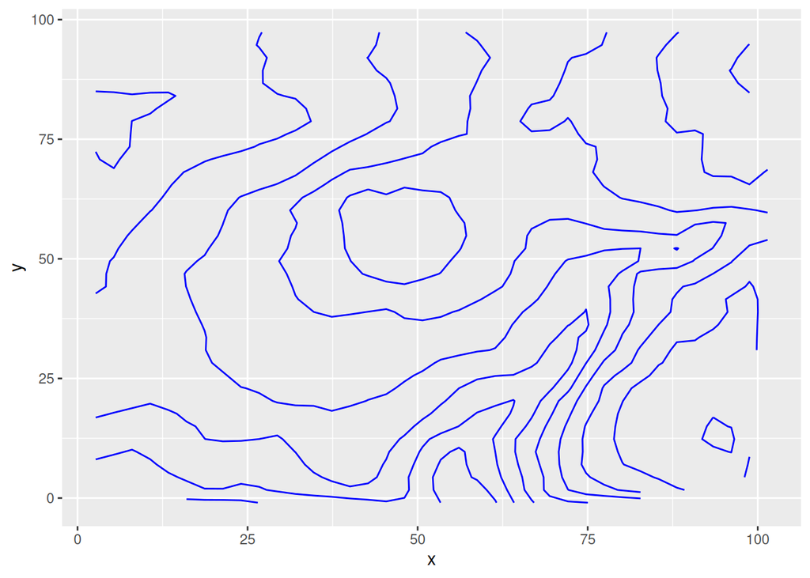

```r
try(example('ggplot_contour_data', package = 'TateyamaVegetation', echo=TRUE, ask=FALSE), silent = TRUE)
```

## 43 `hindo`

**Documentation:**

```
頻度のギリシャ文字変換(小島書式)

Description:

     頻度のギリシャ文字変換(小島書式)

Usage:

     hindo(r)

Arguments:

       r:

Examples:

     sapply(seq(0,1,.1),hindo)
```

**Examples (from .Rd):**

```r
### Name: hindo
### Title: 頻度のギリシャ文字変換(小島書式)
### Aliases: hindo

### ** Examples

sapply(seq(0,1,.1),hindo)
```

**Executed Example:**

```r
try(example('hindo', package = 'TateyamaVegetation', echo=TRUE, ask=FALSE), silent = TRUE)
```

```
##
## hindo> sapply(seq(0,1,.1),hindo)
##  [1] "-" "Ⅰ" "Ⅰ" "Ⅱ" "Ⅱ" "Ⅲ" "Ⅳ" "Ⅳ" "Ⅳ" "Ⅴ" "Ⅴ"
```

## 44 `html_family_label`

**Documentation:**

```
html科名ラベル html植物目録作成用
種名と科名を列に含んだデータフレームを入力し科名のhtmlラベルを出力する

Description:

     html科名ラベル html植物目録作成用
     種名と科名を列に含んだデータフレームを入力し科名のhtmlラベルを出力する

Usage:

     html_family_label(species_list)

Arguments:

species_list:

Examples:

     spj <- c("ブナ","コナラ","スギ","アカミノイヌツゲ","イタヤカエデ","アオカラムシ","ミズナラ")
     species_list <- APG[match(spj,APG$種名),]

     html_family_label(species_list)
```

**Examples (from .Rd):**

```r
### Name: html_family_label
### Title: html科名ラベル html植物目録作成用
###   種名と科名を列に含んだデータフレームを入力し科名のhtmlラベルを出力する
### Aliases: html_family_label

### ** Examples

spj <- c("ブナ","コナラ","スギ","アカミノイヌツゲ","イタヤカエデ","アオカラムシ","ミズナラ")
species_list <- APG[match(spj,APG$種名),]

html_family_label(species_list)
```

**Executed Example:**

```r
try(example('html_family_label', package = 'TateyamaVegetation', echo=TRUE, ask=FALSE), silent = TRUE)
```

```
##
## html__> spj <- c("ブナ","コナラ","スギ","アカミノイヌツゲ","イタヤカエデ","アオカラムシ","ミズナラ")
##
## html__> species_list <- APG[match(spj,APG$種名),]
##
## html__> html_family_label(species_list)
## [1] "<tr><td height=30 valign=\"bottom\"><font size=+1; face='Arial'>FAGACEAE&emsp;ブナ科</font></td></tr>\n"
## [2] "<tr><td height=30 valign=\"bottom\"><font size=+1; face='Arial'>FAGACEAE&emsp;ブナ科</font></td></tr>\n"
## [3] "<tr><td height=30 valign=\"bottom\"><font size=+1; face='Arial'>CUPRESSACEAE&emsp;ヒノキ科</font></td></tr>\n"
## [4] "<tr><td height=30 valign=\"bottom\"><font size=+1; face='Arial'>AQUIFOLIACEAE&emsp;モチノキ科</font></td></tr>\n"
## [5] "<tr><td height=30 valign=\"bottom\"><font size=+1; face='Arial'>SAPINDACEAE&emsp;ムクロジ科</font></td></tr>\n"
## [6] "<tr><td height=30 valign=\"bottom\"><font size=+1; face='Arial'>URTICACEAE&emsp;イラクサ科</font></td></tr>\n"
## [7] "<tr><td height=30 valign=\"bottom\"><font size=+1; face='Arial'>FAGACEAE&emsp;ブナ科</font></td></tr>\n"
```

## 45 `html_science_name`

**Documentation:**

```
html書式　属名・種小名をイタリックにする

Description:

     html書式　属名・種小名をイタリックにする

Usage:

     html_science_name(sn0)

Arguments:

     sn0:

Examples:

     html_science_name("Quercus serrata Thunb. ex. Muuray")
```

**Examples (from .Rd):**

```r
### Name: html_science_name
### Title: html書式　属名・種小名をイタリックにする
### Aliases: html_science_name

### ** Examples

html_science_name("Quercus serrata Thunb. ex. Muuray")
```

**Executed Example:**

```r
try(example('html_science_name', package = 'TateyamaVegetation', echo=TRUE, ask=FALSE), silent = TRUE)
```

```
##
## html__> html_science_name("Quercus serrata Thunb. ex. Muuray")
## [1] "<i>Quercus serrata</i> Thunb. ex. Muuray"
```

## 46 `leg`

**Documentation:**

```
data/leg　図凡例

Description:

     data/leg　図凡例

Usage:

     data(leg)

Format:

     An object of class `data.frame`.

Source:

     automatically generated skeleton

Examples:

     leg
```

**Examples (from .Rd):**

```r
### Name: leg
### Title: data/leg　図凡例
### Aliases: leg
### Keywords: datasets

### ** Examples

leg
```

**Executed Example:**

```r
try(example('leg', package = 'TateyamaVegetation', echo=TRUE, ask=FALSE), silent = TRUE)
```

```
##
## leg> leg
##               n             col pch lty
## 1     Bijodaira          brown1   4   2
## 2      Bunazaka darkolivegreen3  13   1
## 3     Bunadaira darkolivegreen4  13   2
## 4 Kaminokodaira      blueviolet  11   2
## 5    Matsuotoge            blue  17   2
## 6       Mimatsu           blue4   2   1
## 7    Kagamiishi           cyan3   8   2
## 8       Arimine     chartreuse3   1   2
```

## 47 `package_docs_with_examples`

**Documentation:**

```
Generate Package Documentation with Examples and Knit to HTML

Description:

     Generate Package Documentation with Examples and Knit to HTML

Usage:

     package_docs_with_examples(
       package_name,
       output_rmd = "package_docs_with_examples.Rmd",
       output_html = "package_docs_with_examples.html"
     )

Arguments:

package_name: The name of the package (character string)

output_rmd: The output Rmd filename (default:
          "package_docs_with_examples.Rmd")

output_html: The output HTML filename (default:
          "package_docs_with_examples.html")

Value:

     None. The Rmd and HTML files are generated in the current working
     directory.

Examples:

     package_docs_with_examples("TateyamaVegetation")
```

**Examples (from .Rd):**

```r
### Name: package_docs_with_examples
### Title: Generate Package Documentation with Examples and Knit to HTML
### Aliases: package_docs_with_examples

### ** Examples

package_docs_with_examples("TateyamaVegetation")
```

**Executed Example:**

```r
try(example('package_docs_with_examples', package = 'TateyamaVegetation', echo=TRUE, ask=FALSE), silent = TRUE)
```

```
##
## pck___> package_docs_with_examples("TateyamaVegetation")
```

```
## ✅ Rmd生成完了: package_docs_with_examples.Rmd
```

```
## 🧶 RmdをHTMLに変換中...
```

## 48 `plots_5periods_sum`

**Documentation:**

```
種の被度の時系列変化　(例　ササの経年変化作図) Change of coverage for
floral types (life form species)

Description:

     種の被度の時系列変化　(例　ササの経年変化作図) Change of coverage
     for floral types (life form species)

Usage:

     plots_5periods_sum(data = d, condition = form == "sasa")

Arguments:

    data: A tibble with columns `form`, `plot`, and `c1:c5`.

Value:

     Summarised tibble.

Examples:

     library(magrittr)
     library(tidyr)
     library(dplyr)
     library(ggplot2)

      d<-plots_5periods_sum(data=vc5,condition=form == "sasa")
     # c2〜c5をロング化


     d_long <- d %>%
       select(plot, c2:c5) %>%
       pivot_longer(c2:c5, names_to = "period", values_to = "value") %>%
       mutate(period = factor(period, levels = c("c2","c3","c4","c5")))

     # 各plotを別パネル
     ggplot(d_long, aes(x = period, y = value, group = plot)) +
       geom_line() +
       geom_point() +
       facet_wrap(~ plot, scales = "free_y") +
       labs(x = "Period", y = "Coverage", title = "Change in c2–c5 by plot") +
       theme_minimal()


     # 1枚で表示
     shapes <- c(15, 16, 17, 18, 19, 20, 21, 22, 23)

     ggplot(d_long, aes(x = period, y = value,
                        color = plot,
                        shape = plot,
                        group = plot)) +
       geom_line() +
       geom_point(size = 3) +
       scale_shape_manual(values = shapes) +
       labs(x = "Period", y = "Coverage",
            title = "Change in c2–c5 (all plots)") +
       theme_minimal()

     #'
```

**Examples (from .Rd):**

```r
### Name: plots_5periods_sum
### Title: 種の被度の時系列変化　(例　ササの経年変化作図) Change of
###   coverage for floral types (life form species)
### Aliases: plots_5periods_sum

### ** Examples

library(magrittr)
library(tidyr)
library(dplyr)
library(ggplot2)

 d<-plots_5periods_sum(data=vc5,condition=form == "sasa")
# c2〜c5をロング化


d_long <- d %>%
  select(plot, c2:c5) %>%
  pivot_longer(c2:c5, names_to = "period", values_to = "value") %>%
  mutate(period = factor(period, levels = c("c2","c3","c4","c5")))

# 各plotを別パネル
ggplot(d_long, aes(x = period, y = value, group = plot)) +
  geom_line() +
  geom_point() +
  facet_wrap(~ plot, scales = "free_y") +
  labs(x = "Period", y = "Coverage", title = "Change in c2–c5 by plot") +
  theme_minimal()


# 1枚で表示
shapes <- c(15, 16, 17, 18, 19, 20, 21, 22, 23)

ggplot(d_long, aes(x = period, y = value,
                   color = plot,
                   shape = plot,
                   group = plot)) +
  geom_line() +
  geom_point(size = 3) +
  scale_shape_manual(values = shapes) +
  labs(x = "Period", y = "Coverage",
       title = "Change in c2–c5 (all plots)") +
  theme_minimal()

#'
```

**Executed Example:**

```
##
## plt_5_> library(magrittr)
##
## plt_5_> library(tidyr)
##
## plt_5_> library(dplyr)
##
## plt_5_> library(ggplot2)
##
## plt_5_>  d<-plots_5periods_sum(data=vc5,condition=form == "sasa")
##
## plt_5_> # c2〜c5をロング化
## plt_5_>
## plt_5_>
## plt_5_> d_long <- d %>%
## plt_5_+   select(plot, c2:c5) %>%
## plt_5_+   pivot_longer(c2:c5, names_to = "period", values_to = "value") %>%
## plt_5_+   mutate(period = factor(period, levels = c("c2","c3","c4","c5")))
##
## plt_5_> # 各plotを別パネル
## plt_5_> ggplot(d_long, aes(x = period, y = value, group = plot)) +
## plt_5_+   geom_line() +
## plt_5_+   geom_point() +
## plt_5_+   facet_wrap(~ plot, scales = "free_y") +
## plt_5_+   labs(x = "Period", y = "Coverage", title = "Change in c2–c5 by plot") +
## plt_5_+   theme_minimal()
```

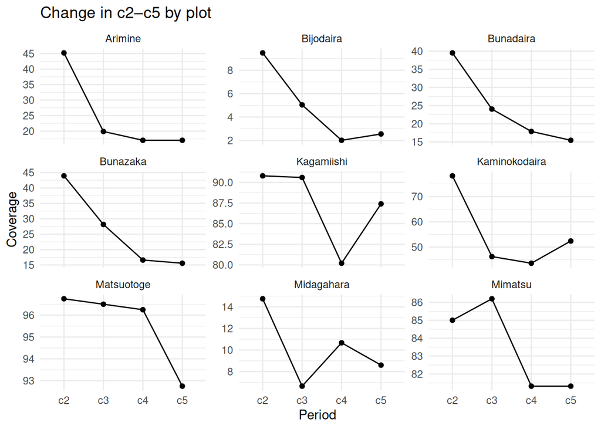

```
##
## plt_5_> # 1枚で表示
## plt_5_> shapes <- c(15, 16, 17, 18, 19, 20, 21, 22, 23)
##
## plt_5_> ggplot(d_long, aes(x = period, y = value,
## plt_5_+                    color = plot,
## plt_5_+                    shape = plot,
## plt_5_+                    group = plot)) +
## plt_5_+   geom_line() +
## plt_5_+   geom_point(size = 3) +
## plt_5_+   scale_shape_manual(values = shapes) +
## plt_5_+   labs(x = "Period", y = "Coverage",
## plt_5_+        title = "Change in c2–c5 (all plots)") +
## plt_5_+   theme_minimal()
```

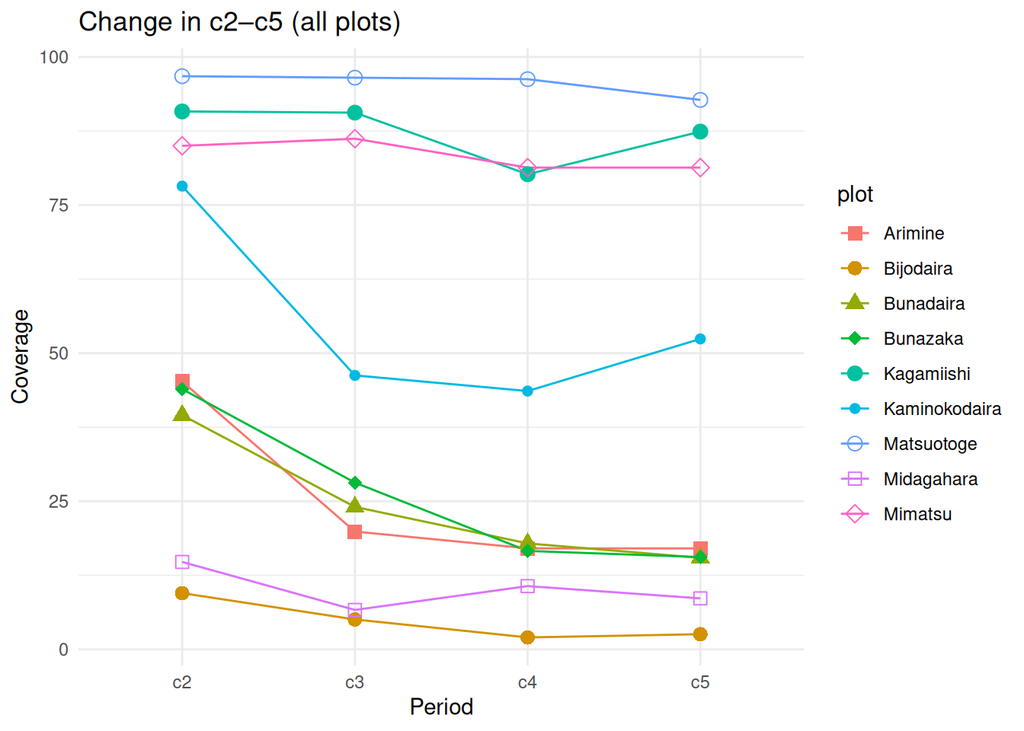

```
##
## plt_5_> #'
## plt_5_>
## plt_5_>
## plt_5_>
```

```r
try(example('plots_5periods_sum', package = 'TateyamaVegetation', echo=TRUE, ask=FALSE), silent = TRUE)
```

## 49 `plt`

**Documentation:**

```
data/plt

Description:

     data/plt

Usage:

     data(plt)

Format:

     An object of class `data.frame`.

Source:

     automatically generated skeleton

Examples:

     plt
```

**Examples (from .Rd):**

```r
### Name: plt
### Title: data/plt
### Aliases: plt
### Keywords: datasets

### ** Examples

plt
```

**Executed Example:**

```r
try(example('plt', package = 'TateyamaVegetation', echo=TRUE, ask=FALSE), silent = TRUE)
```

```
##
## plt> plt
## # A tibble: 10 × 34
##       no plot_name_jp plot_name    code  latitude longitude altitude plot_width plot_height  area subplots_width subplots_height subplots_area subplot_width subplot_height subplots_n
##    <dbl> <chr>        <chr>        <chr>    <dbl>     <dbl>    <dbl>      <dbl>       <dbl> <dbl>          <dbl>           <dbl>         <dbl>         <dbl>          <dbl>      <dbl>
##  1     1 美女平       Bijodaira    A         36.6      137.     1040        100         100 10000             50              50          2500            10             10         25
##  2     2 ブナ坂       Bunazaka     B         36.6      137.     1090        100         100 10000             40              70          2800            10             10         28
##  3     3 ブナ平       Bunadaira    E         36.6      137.     1190        100         100 10000             50              50          2500            10             10         25
##  4     4 上ノ小平     Kaminokodai… H         36.6      138.     1430        100         100 10000             50              50          2500            10             10         25
##  5     5 弥陀ヶ原     Midagahara   D         36.6      138.     1890          5         100   500              5             100           500             5              5         20
##  6     6 美松         Mimatsu      F         36.6      138.     1960         50         100  5000             50              50          2500            10             10         25
##  7     7 松尾峠       Matsuotoge   C         36.6      138.     1970         50         100  5000            100              50          5000            10             10         20
##  8     8 鏡石         Kagamiishi   G         36.6      138.     2250         25          25   625             25              25           625             5              5         25
##  9     9 浄土山       Joudosan     I         36.6      138.     2830         15          15   225             15              15           225             3              3         25
## 10    10 有峰         Arimine      J         36.5      137.     1350        100         100 10000             50              50          2500            10             10         25
## # ℹ 18 more variables: temperature <dbl>, wi <dbl>, ci <dbl>, precipitation <dbl>, snowdepth <dbl>, forest_survey <chr>, dominants <chr>, Forest001 <chr>, Forest002 <chr>,
## #   Forest003 <chr>, Forest004 <chr>, Forest005 <chr>, Forest006 <chr>, Vegetation001 <chr>, Vegetation002 <dbl>, Vegetation003 <chr>, Vegetation004 <chr>, Vegetation005 <chr>
```

## 50 `rasXYZ`

**Documentation:**

```
data/各調査区等高線用ラスタデータrasXYZ

Description:

     data/各調査区等高線用ラスタデータrasXYZ

Usage:

     data(rasXYZ)

Format:

     An object of class `list`.

Source:

     automatically generated skeleton

Examples:

     par(mfrow=c(3,3))
     for(i in 1:nrow(plt)){
      contour(rasXYZ[[i]],main=plt$na[i])
     }
```

**Examples (from .Rd):**

```r
### Name: rasXYZ
### Title: data/各調査区等高線用ラスタデータrasXYZ
### Aliases: rasXYZ
### Keywords: datasets

### ** Examples

par(mfrow=c(3,3))
for(i in 1:nrow(plt)){
 contour(rasXYZ[[i]],main=plt$na[i])
}
```

**Executed Example:**

```r
try(example('rasXYZ', package = 'TateyamaVegetation', echo=TRUE, ask=FALSE), silent = TRUE)
```

```
##
## rasXYZ> par(mfrow=c(3,3))
##
## rasXYZ> for(i in 1:nrow(plt)){
## rasXYZ+  contour(rasXYZ[[i]],main=plt$na[i])
## rasXYZ+ }
```

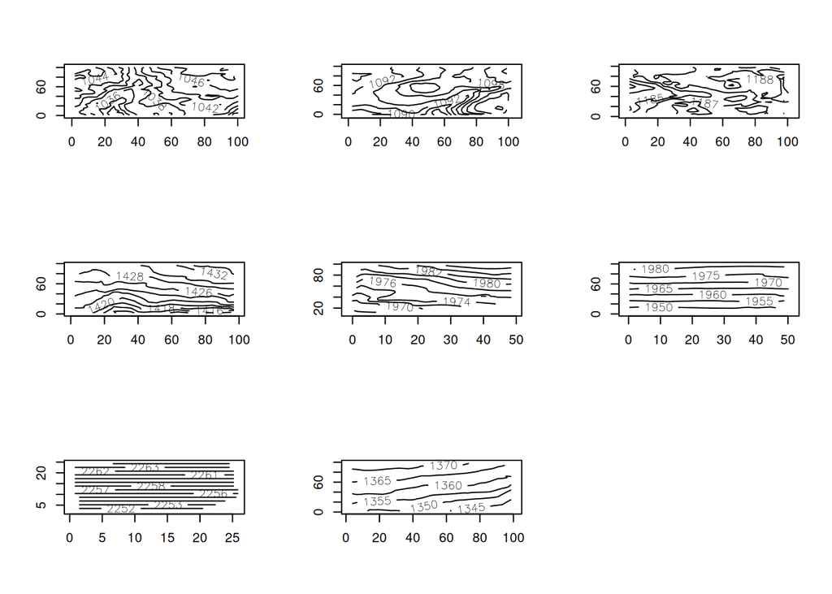

## 51 `sp_exc`

**Documentation:**

```
data/sp_exc　同種異名(シノニム)の変換表です
sp_naからsp_na2に統一しました

Description:

     data/sp_exc　同種異名(シノニム)の変換表です
     sp_naからsp_na2に統一しました

Usage:

     data(sp_exc)

Format:

     An object of class `data.frame`.

Examples:

     sp_exc
```

**Examples (from .Rd):**

```r
### Name: sp_exc
### Title: data/sp_exc　同種異名(シノニム)の変換表です
###   sp_naからsp_na2に統一しました
### Aliases: sp_exc
### Keywords: datasets

### ** Examples

sp_exc
```

**Executed Example:**

```r
try(example('sp_exc', package = 'TateyamaVegetation', echo=TRUE, ask=FALSE), silent = TRUE)
```

```
##
## sp_exc> sp_exc
##             sp_na                 sp_na2
## 1  メイゲツカエデ         ハウチワカエデ
## 2      ナライシダ       ホソバナライシダ
## 3      フタバラン           コフタバラン
## 4  オオバユキザサ         ヤマトユキザサ
## 5    コイワカガミ             イワカガミ
## 6          クロベ                 ネズコ
## 7  ニッコウキスゲ             ゼンテイカ
## 8  カヤツリグサ科         カヤツリグサ科
## 9    ミツバツツジ       ホンミツバツツジ
## 10     コガネギク ミヤマアキノキリンソウ
## 11           水面                   水面
## 12             イ                 イグサ
## 13     コゴメグサ       イブキコゴメグサ
## 14 タテヤマオウギ             イワオウギ
```

## 52 `sptype`

**Documentation:**

```
data/sptype コード、生活型、 階層の略号表

Description:

     data/sptype コード、生活型、 階層の略号表

Usage:

     data(sptype)

Format:

     An object of class `data.frame`.

Examples:

     sptype
```

**Examples (from .Rd):**

```r
### Name: sptype
### Title: data/sptype コード、生活型、 階層の略号表
### Aliases: sptype
### Keywords: datasets

### ** Examples

sptype
```

**Executed Example:**

```r
try(example('sptype', package = 'TateyamaVegetation', echo=TRUE, ask=FALSE), silent = TRUE)
```

```
##
## sptype> sptype
##    コード     生活型 階層
## 1      bl 広葉樹高木   B2
## 2      bs 広葉樹低木   B2
## 3     cds   ハイマツ   B2
## 4      cl 針葉樹高木   B2
## 5      cs 針葉樹低木   B2
## 6      ds   矮性低木    C
## 7       f       シダ    C
## 8       h       草本    C
## 9       l         蔓    L
## 10   sasa       ササ    S
## 11      w       水面    w
```

## 53 `subplot_xy`

**Documentation:**

```
data/ 各調査地におけるサブプロットの位置座標

Description:

     data/ 各調査地におけるサブプロットの位置座標

Usage:

     data(subplot_xy)

Format:

     An object of class `data.frame`.

Examples:

     subplot_xy
```

**Examples (from .Rd):**

```r
### Name: subplot_xy
### Title: data/ 各調査地におけるサブプロットの位置座標
### Aliases: subplot_xy
### Keywords: datasets

### ** Examples

subplot_xy
```

**Executed Example:**

```r
try(example('subplot_xy', package = 'TateyamaVegetation', echo=TRUE, ask=FALSE), silent = TRUE)
```

```
##
## sbplt_> subplot_xy
##              plot    x    y subplot
## 1       Bijodaira 55.0 55.0       1
## 2       Bijodaira 55.0 65.0       2
## 3       Bijodaira 55.0 75.0       3
## 4       Bijodaira 55.0 85.0       4
## 5       Bijodaira 55.0 95.0       5
## 6       Bijodaira 65.0 55.0       6
## 7       Bijodaira 65.0 65.0       7
## 8       Bijodaira 65.0 75.0       8
## 9       Bijodaira 65.0 85.0       9
## 10      Bijodaira 65.0 95.0      10
## 11      Bijodaira 75.0 55.0      11
## 12      Bijodaira 75.0 65.0      12
```

[output cut: 239 more lines]

## 54 `subplot_xy_ggtext`

**Documentation:**

```
樹木位置図　樹木位置・ラベル・種名・ランドマーク・コンタ・サブプロット・グリッド

Description:

     樹木位置図　樹木位置・ラベル・種名・ランドマーク・コンタ・サブプロット・グリッド

Usage:

     subplot_xy_ggtext(plot.name = "Mimatsu")

Arguments:

plot.name:

Examples:

     (p<-treemap(plot.name="Mimatsu"))
     p+subplot_xy_ggtext("Mimatsu")
```

**Examples (from .Rd):**

```r
### Name: subplot_xy_ggtext
### Title:
###   樹木位置図　樹木位置・ラベル・種名・ランドマーク・コンタ・サブプロット・グリッド
### Aliases: subplot_xy_ggtext

### ** Examples

(p<-treemap(plot.name="Mimatsu"))
p+subplot_xy_ggtext("Mimatsu")
```

**Executed Example:**

```
##
## sbpl__> (p<-treemap(plot.name="Mimatsu"))
```

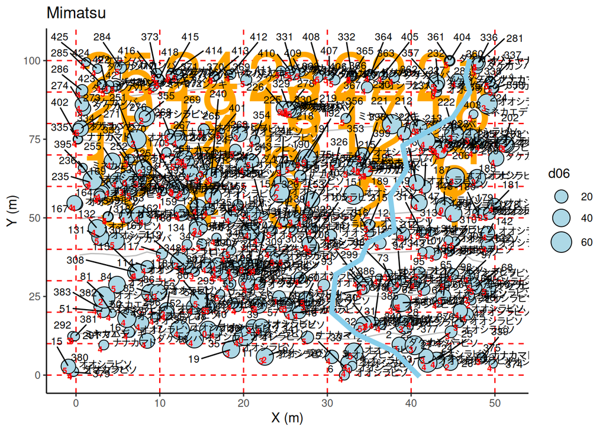

```
##
## sbpl__> p+subplot_xy_ggtext("Mimatsu")
```

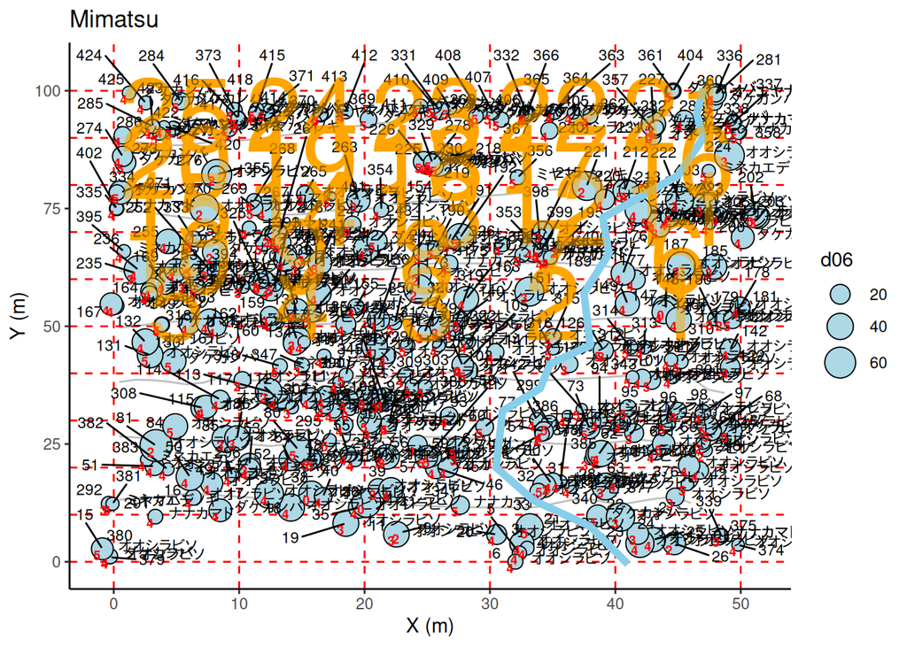

```r
try(example('subplot_xy_ggtext', package = 'TateyamaVegetation', echo=TRUE, ask=FALSE), silent = TRUE)
```

## 55 `subplot_xy_text`

**Documentation:**

```
各調査区におけるサブプロット位置
plotで描画したキャンバスにtextで上書きするコマンド

Description:

     各調査区におけるサブプロット位置
     plotで描画したキャンバスにtextで上書きするコマンド

Usage:

     subplot_xy_text(plot.name = "Mimatsu", ...)

Arguments:

plot.name:

Examples:

     plot(1:100,type="n")
     subplot_xy_text(plot.name="Mimatsu",col="red",cex=3)
     subplot_xy_text(plot.name="Arimine",col="Blue",cex=2)
     subplot_xy_text(plot.name="Kaminokodaira",col="Magenta",cex=2)
```

**Examples (from .Rd):**

```r
### Name: subplot_xy_text
### Title: 各調査区におけるサブプロット位置
###   plotで描画したキャンバスにtextで上書きするコマンド
### Aliases: subplot_xy_text

### ** Examples

plot(1:100,type="n")
subplot_xy_text(plot.name="Mimatsu",col="red",cex=3)
subplot_xy_text(plot.name="Arimine",col="Blue",cex=2)
subplot_xy_text(plot.name="Kaminokodaira",col="Magenta",cex=2)
```

**Executed Example:**

```
##
## sbpl__> plot(1:100,type="n")
```

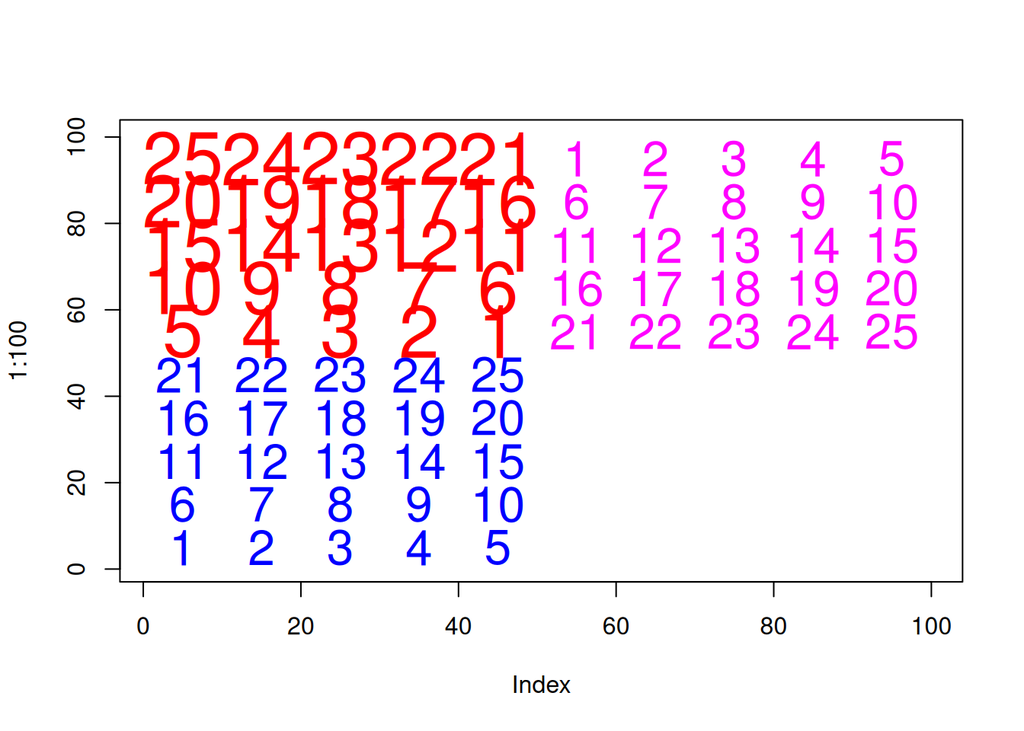

```
##
## sbpl__> subplot_xy_text(plot.name="Mimatsu",col="red",cex=3)
##
## sbpl__> subplot_xy_text(plot.name="Arimine",col="Blue",cex=2)
##
## sbpl__> subplot_xy_text(plot.name="Kaminokodaira",col="Magenta",cex=2)
```

```r
try(example('subplot_xy_text', package = 'TateyamaVegetation', echo=TRUE, ask=FALSE), silent = TRUE)
```

## 56 `topo`

**Documentation:**

```
data/ 各調査区の沢や歩道の座標(中島さん)

Description:

     data/ 各調査区の沢や歩道の座標(中島さん)

Usage:

     data(topo)

Format:

     An object of class `data.frame`.

Examples:

     topo
```

**Examples (from .Rd):**

```r
### Name: topo
### Title: data/ 各調査区の沢や歩道の座標(中島さん)
### Aliases: topo
### Keywords: datasets

### ** Examples

topo
```

**Executed Example:**

```r
try(example('topo', package = 'TateyamaVegetation', echo=TRUE, ask=FALSE), silent = TRUE)
```

```
##
## topo> topo
##          plot      sp      lb      x      y        z                           memo
## 1   Bijodaira stream1   渓流1  31.31   0.32 1029.983
## 2   Bijodaira stream1   渓流2  30.01   5.20 1030.603
## 3   Bijodaira stream1   渓流3  27.54  10.57 1031.363
## 4   Bijodaira stream1   渓流4  25.00  16.99 1031.563
## 5   Bijodaira stream1   渓流5  24.45  20.55 1031.692
## 6   Bijodaira stream1   渓流6  25.55  25.05 1032.322
## 7   Bijodaira stream1   渓流7  29.89  33.21 1033.082
## 8   Bijodaira stream1   渓流8  34.74  43.03 1034.082
## 9   Bijodaira stream1   渓流9  35.98  54.16 1035.312
## 10  Bijodaira stream1  渓流10  40.02  66.54 1036.603
## 11  Bijodaira stream1  渓流11  40.21  72.13 1037.203
## 12  Bijodaira stream1  渓流12  38.96  80.24 1038.103
```

[output cut: 131 more lines]

## 57 `topo_gg`

**Documentation:**

```
樹木位置図(ggplot　ラベル情報なし) 調査用にはtreemapを利用してください

Description:

     樹木位置図(ggplot　ラベル情報なし)
     調査用にはtreemapを利用してください

Usage:

     topo_gg(plot.name = "Mimatsu")

Arguments:

plot.name:

Examples:

     x11()
     pn<-"Mimatsu"
      pn<-"Bijodaira"
     (p<-treemap(plot.name=pn))
     p+topo_gg(pn)
     p+stream1
```

**Examples (from .Rd):**

```r
### Name: topo_gg
### Title: 樹木位置図(ggplot　ラベル情報なし)
###   調査用にはtreemapを利用してください
### Aliases: topo_gg

### ** Examples

x11()
pn<-"Mimatsu"
 pn<-"Bijodaira"
(p<-treemap(plot.name=pn))
p+topo_gg(pn)
p+stream1
```

**Executed Example:**

```r
try(example('topo_gg', package = 'TateyamaVegetation', echo=TRUE, ask=FALSE), silent = TRUE)
```

[output not shown]

```
##
## top_gg> x11()
##
## top_gg> pn<-"Mimatsu"
##
## top_gg>  pn<-"Bijodaira"
##
## top_gg> (p<-treemap(plot.name=pn))
```

```
##
## top_gg> p+topo_gg(pn)
```

## 58 `treemap`

**Documentation:**

```
植生調査用樹木位置図作成

Description:

     植生調査用樹木位置図作成

Usage:

     treemap(plot.name = "Mimatsu")

Arguments:

      df:

Examples:

     #  x11()
     treemap("Bijodaira")
     treemap("Bunazaka")
     treemap("Bunadaira")
     treemap("Kaminokodaira")
     treemap("Matsuotoge")
     treemap("Kagamiishi")

     #'
     treemap("Mimatsu")
      treemap("Mimatsu")+ ggplot2::ylim(c(45, 105))


     treemap("Arimine")
      treemap("Arimine")+ ggplot2::xlim(c(-5, 55))+ ggplot2::ylim(c(-5, 60))





     #'
```

**Examples (from .Rd):**

```r
### Name: treemap
### Title: 植生調査用樹木位置図作成
### Aliases: treemap

### ** Examples


#  x11()
treemap("Bijodaira")
treemap("Bunazaka")
treemap("Bunadaira")
treemap("Kaminokodaira")
treemap("Matsuotoge")
treemap("Kagamiishi")

#'
treemap("Mimatsu")
 treemap("Mimatsu")+ ggplot2::ylim(c(45, 105))


treemap("Arimine")
 treemap("Arimine")+ ggplot2::xlim(c(-5, 55))+ ggplot2::ylim(c(-5, 60))





#'
```

**Executed Example:**

```r
try(example('treemap', package = 'TateyamaVegetation', echo=TRUE, ask=FALSE), silent = TRUE)
```

```
##
## treemp> #  x11()
## treemp> treemap("Bijodaira")
```

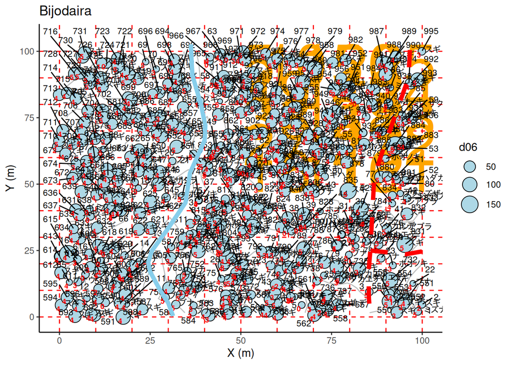

```
##
## treemp> treemap("Bunazaka")
```

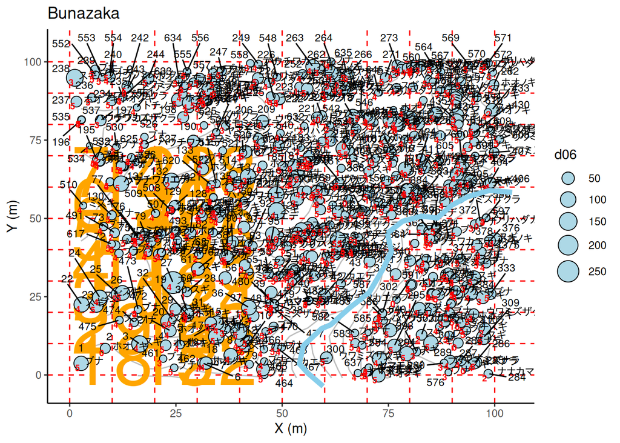

```
##
## treemp> treemap("Bunadaira")
```

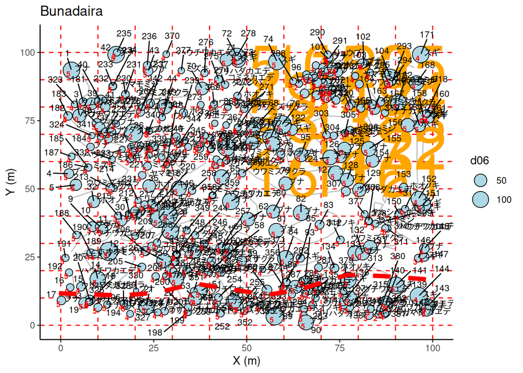

```
##
## treemp> treemap("Kaminokodaira")
```

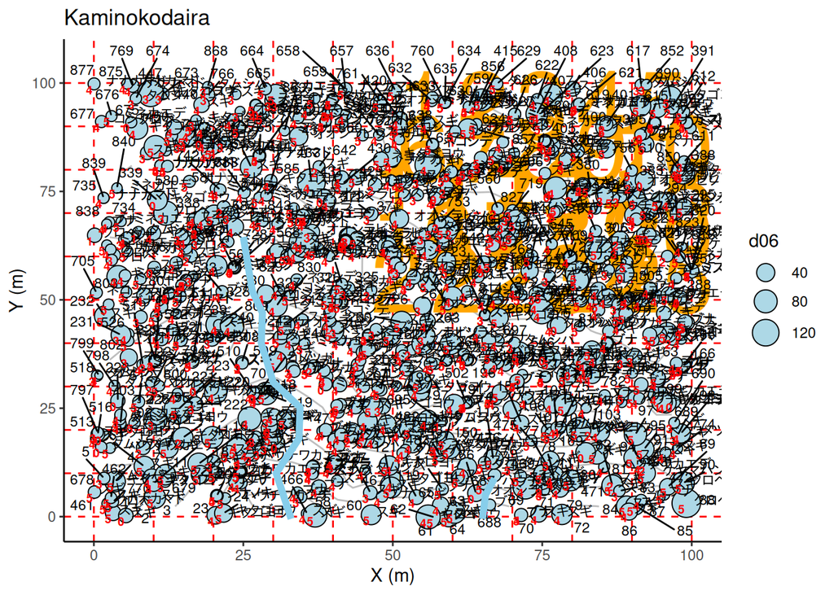

```
##
## treemp> treemap("Matsuotoge")
```

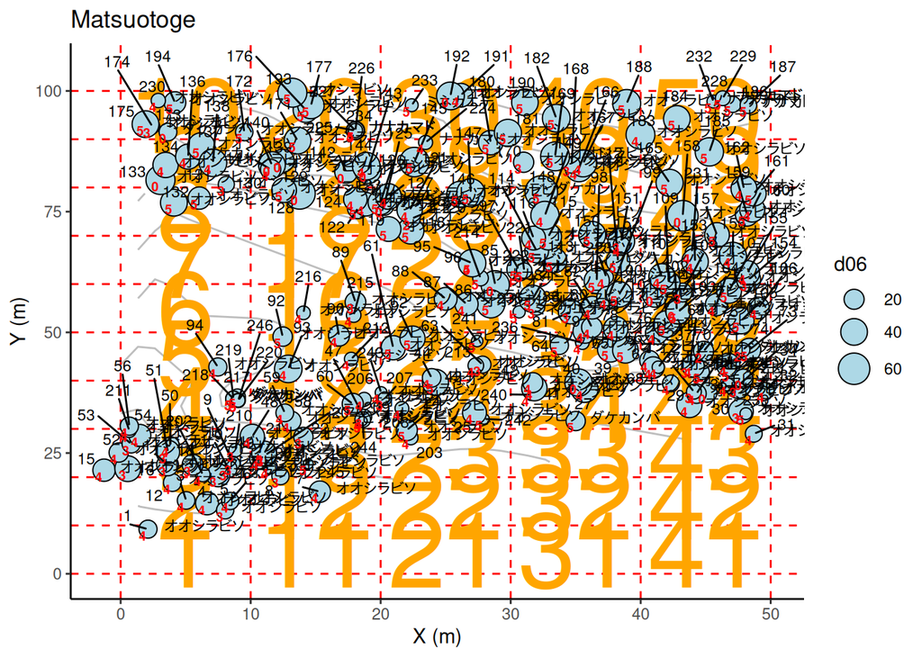

```
##
## treemp> treemap("Kagamiishi")
```

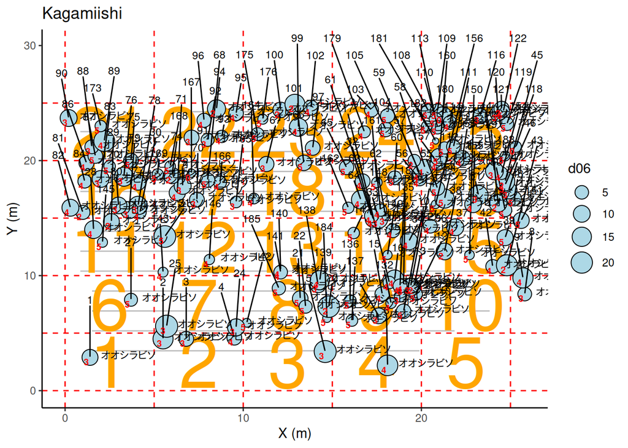

```
##
## treemp> #'
## treemp> treemap("Mimatsu")
```

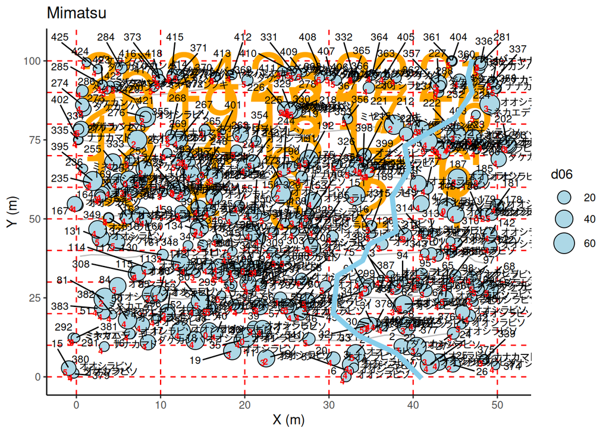

```
##
## treemp>  treemap("Mimatsu")+ ggplot2::ylim(c(45, 105))
```

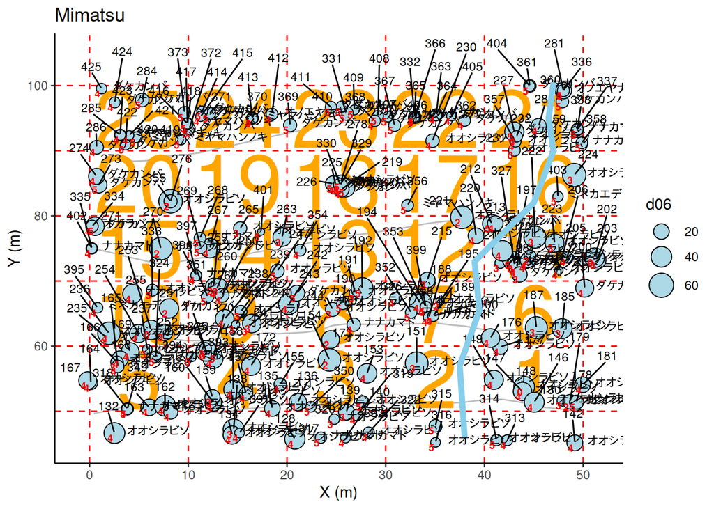

```
##
## treemp> treemap("Arimine")
```

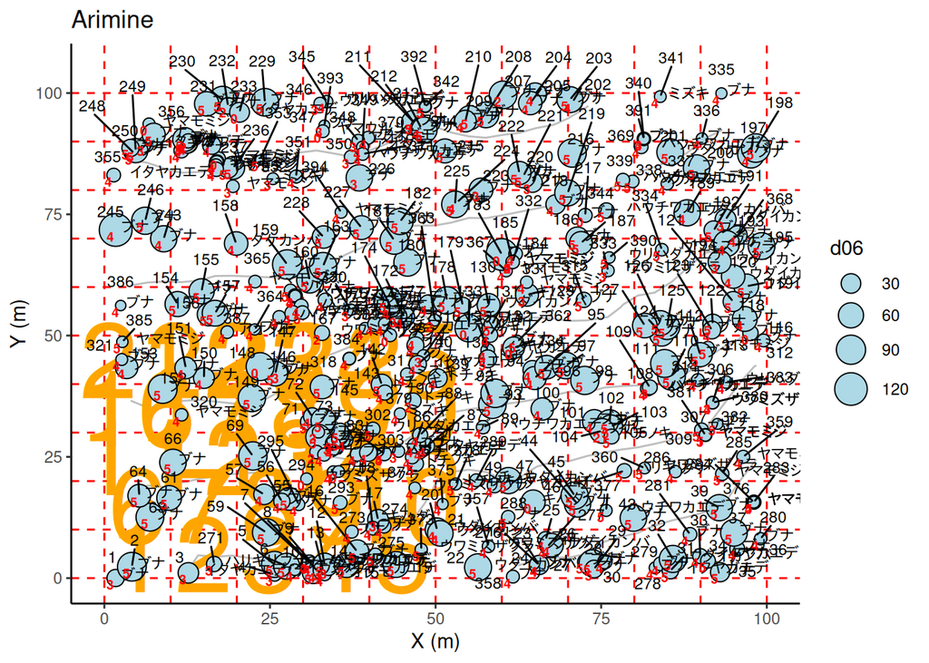

```
##
## treemp>  treemap("Arimine")+ ggplot2::xlim(c(-5, 55))+ ggplot2::ylim(c(-5, 60))
```

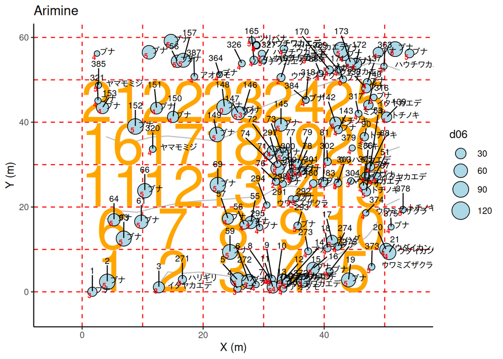

```
##
## treemp> #'
## treemp>
## treemp>
## treemp>
```

## 59 `treemap_ggplot`

**Documentation:**

```
樹木位置図(ggplt2) 木が混み合っていてもラベルが重ならないように図化

Description:

     樹木位置図(ggplt2)
     木が混み合っていてもラベルが重ならないように図化

Usage:

     treemap_ggplot(df)

Arguments:

      df:

Examples:

     df <- data.frame(
     x = runif(30, 0, 100),
     y = runif(30, 0, 100),
     z = runif(30, 0, 100),
     dbh = runif(30, 10, 50),
     id = paste0(100:129),
     species = sample(c("A1", "B2", "C3"), 30, replace = TRUE),
     vigor = sample(1:5, 30, replace = TRUE)
     )
     treemap_ggplot(df)
     #'
```

**Examples (from .Rd):**

```r
### Name: treemap_ggplot
### Title: 樹木位置図(ggplt2)
###   木が混み合っていてもラベルが重ならないように図化
### Aliases: treemap_ggplot

### ** Examples


df <- data.frame(
x = runif(30, 0, 100),
y = runif(30, 0, 100),
z = runif(30, 0, 100),
dbh = runif(30, 10, 50),
id = paste0(100:129),
species = sample(c("A1", "B2", "C3"), 30, replace = TRUE),
vigor = sample(1:5, 30, replace = TRUE)
)
treemap_ggplot(df)
#'
```

**Executed Example:**

```
##
## trmp_g> df <- data.frame(
## trmp_g+ x = runif(30, 0, 100),
## trmp_g+ y = runif(30, 0, 100),
## trmp_g+ z = runif(30, 0, 100),
## trmp_g+ dbh = runif(30, 10, 50),
## trmp_g+ id = paste0(100:129),
## trmp_g+ species = sample(c("A1", "B2", "C3"), 30, replace = TRUE),
## trmp_g+ vigor = sample(1:5, 30, replace = TRUE)
## trmp_g+ )
##
## trmp_g> treemap_ggplot(df)
```

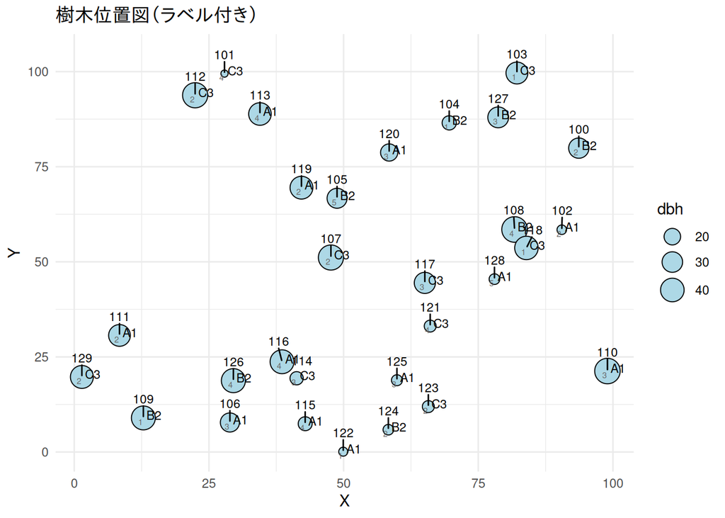

```
##
## trmp_g> #'
## trmp_g>
## trmp_g>
## trmp_g>
```

```r
try(example('treemap_ggplot', package = 'TateyamaVegetation', echo=TRUE, ask=FALSE), silent = TRUE)
```

## 60 `treesXYZ`

**Documentation:**

```
data/ 各調査区樹木位置座標

Description:

     data/ 各調査区樹木位置座標

Usage:

     data(treesXYZ)

Format:

     An object of class `data.frame`.

Examples:

     treesXYZ
```

**Examples (from .Rd):**

```r
### Name: treesXYZ
### Title: data/ 各調査区樹木位置座標
### Aliases: treesXYZ
### Keywords: datasets

### ** Examples

treesXYZ
```

**Executed Example:**

```r
try(example('treesXYZ', package = 'TateyamaVegetation', echo=TRUE, ask=FALSE), silent = TRUE)
```

```
##
## trsXYZ> treesXYZ
##          plot             sp  lb          x          y        z
## 1   Bijodaira       ミズナラ   1 98.8000000  2.0800000 1033.826
## 2   Bijodaira           スギ   2 99.9200000  4.7000000 1033.256
## 3   Bijodaira           スギ 550 93.0186000  1.7285700 1039.207
## 4   Bijodaira           スギ 551 95.6084000  6.3150500 1039.705
## 5   Bijodaira           スギ 552 94.8704000  4.9388900 1039.143
## 6   Bijodaira           スギ 553 92.3235000  6.8940900 1040.410
## 7   Bijodaira           スギ 554 92.0305000  8.3674200 1041.132
## 8   Bijodaira           スギ 555 90.9334000  8.5062200 1041.089
## 9   Bijodaira           スギ 556 90.8086000  5.8785700 1041.407
## 10  Bijodaira           ブナ   3 85.4036000  9.4255000 1042.486
## 11  Bijodaira           ブナ  87 84.4136000  9.2855000       NA
## 12  Bijodaira           スギ 557 76.6747000  4.5735400 1041.571
```

[output cut: 155 more lines]

## 61 `vegetation_code`

**Documentation:**

```
data/ 植物目録各調査区頻度分布コード
植生モニタリング調査(小島覚・石田仁)

Description:

     data/ 植物目録各調査区頻度分布コード
     植生モニタリング調査(小島覚・石田仁)

Usage:

     data(vv5)

Format:

     An object of class `tbl_df`.

Examples:

     vegetation_code
      SpeciesNameCheck(vegetation_code$sp)
```

**Examples (from .Rd):**

```r
### Name: vegetation_code
### Title: data/ 植物目録各調査区頻度分布コード
###   植生モニタリング調査(小島覚・石田仁)
### Aliases: vegetation_code
### Keywords: datasets

### ** Examples


vegetation_code
 SpeciesNameCheck(vegetation_code$sp)
```

**Executed Example:**

```r
try(example('vegetation_code', package = 'TateyamaVegetation', echo=TRUE, ask=FALSE), silent = TRUE)
```

```
##
## vgttn_> vegetation_code
##                           sp vegetation_code
## 1                   アオダモ   9812-0-0000-0
## 2           アカミノイヌツゲ   1118-0-0120-0
## 3                   アクシバ   3559-0-0000-0
## 4               イタヤカエデ   1000-0-0000-0
## 5             ウリハダカエデ   A971-0-0000-0
## 6             ウワミズザクラ   5961-0-0000-0
## 7               エゾアジサイ   0000-0-0000-0
## 8               エゾユズリハ   2930-0-0000-0
## 9               オオカメノキ   AAAA-0-0700-0
## 10            オオバクロモジ   AAA1-0-0000-0
## 11              オオバスノキ   0015-0-0990-0
## 12              カスミザクラ   0000-0-0000-0
```

[output cut: 288 more lines]

## 62 `vv`

**Documentation:**

```
data/ 1-5期調査区サブプロット植生調査生データ

Description:

     data/ 1-5期調査区サブプロット植生調査生データ

Usage:

     data(vv)

Format:

     An object of class `tbl_df`.

Examples:

     vv
```

**Examples (from .Rd):**

```r
### Name: vv
### Title: data/ 1-5期調査区サブプロット植生調査生データ
### Aliases: vv
### Keywords: datasets

### ** Examples

vv
```

**Executed Example:**

```r
try(example('vv', package = 'TateyamaVegetation', echo=TRUE, ask=FALSE), silent = TRUE)
```

```
##
## vv> vv
## # A tibble: 7,673 × 10
##       pn plot      subplot layer sp                dk01   c02   c03   c04   c05
##    <dbl> <chr>       <dbl> <chr> <chr>            <dbl> <dbl> <dbl> <dbl> <dbl>
##  1     1 Bijodaira       1 B2    アオダモ           0     0     0     0.5   0.5
##  2     1 Bijodaira       1 B2    アカミノイヌツゲ   0.5   0     0     0     0
##  3     1 Bijodaira       1 B2    ウリハダカエデ     0     0     0.5   0.5   0.5
##  4     1 Bijodaira       1 B2    ウワミズザクラ     0     0     0.5   0.5   0.5
##  5     1 Bijodaira       1 B2    エゾアジサイ       3     0     0     0     0
##  6     1 Bijodaira       1 B2    エゾユズリハ       0.5   0     0     0     0
##  7     1 Bijodaira       1 B2    オオカメノキ       5    12    15    11    10
##  8     1 Bijodaira       1 B2    オオバクロモジ     5     3     3     1     2
##  9     1 Bijodaira       1 B2    コシアブラ         0     0.5   0     0     0
## 10     1 Bijodaira       1 B2    コミネカエデ       1     0.5   0.5   0.5   0.5
## # ℹ 7,663 more rows
```

## 63 `vv4`

**Documentation:**

```
data/ 1-4期調査区サブプロット植生調査生データ

Description:

     data/ 1-4期調査区サブプロット植生調査生データ

Usage:

     data(vv4)

Format:

     An object of class `data.frame`.

Source:

     automatically generated skeleton

Examples:

     vv4
```

**Examples (from .Rd):**

```r
### Name: vv4
### Title: data/ 1-4期調査区サブプロット植生調査生データ
### Aliases: vv4
### Keywords: datasets

### ** Examples

vv4
```

**Executed Example:**

```r
try(example('vv4', package = 'TateyamaVegetation', echo=TRUE, ask=FALSE), silent = TRUE)
```

```
##
## vv4> vv4
##     pn      plot subplot layer                 sp dk01  c02  c03  c04  c05
## 1    1 Bijodaira       1    B2           アオダモ  0.0  0.0  0.0  0.5  0.5
## 2    1 Bijodaira       1    B2   アカミノイヌツゲ  0.5  0.0  0.0  0.0  0.0
## 3    1 Bijodaira       1    B2     ウリハダカエデ  0.0  0.0  0.5  0.5  0.5
## 4    1 Bijodaira       1    B2     ウワミズザクラ  0.0  0.0  0.5  0.5  0.5
## 5    1 Bijodaira       1    B2       エゾアジサイ  3.0  0.0  0.0  0.0  0.0
## 6    1 Bijodaira       1    B2       エゾユズリハ  0.5  0.0  0.0  0.0  0.0
## 7    1 Bijodaira       1    B2       オオカメノキ  5.0 12.0 15.0 11.0 10.0
## 8    1 Bijodaira       1    B2     オオバクロモジ  5.0  3.0  3.0  1.0  2.0
## 9    1 Bijodaira       1    B2         コシアブラ  0.0  0.5  0.0  0.0  0.0
## 10   1 Bijodaira       1    B2       コミネカエデ  1.0  0.5  0.5  0.5  0.5
## 11   1 Bijodaira       1    B2         サワフタギ  3.0  1.0  0.5  0.5  0.5
## 12   1 Bijodaira       1    B2           タムシバ  0.0  0.0  0.5  0.0  0.0
```

[output cut: 89 more lines]